# Proof of concept: CO2 capture with PCET-based pH swings

```r
weight.fun = function(pCO2.lean){
  # Ideal
  n.inlet = c(0.15, 0.85)
  n.lean = c(0.85, 0.015*0.85/(1 - 0.015))
  n.enrich = c(0.001*(1 - 0.015*0.85/(1 - 0.015)), 1 - 0.015*0.85/(1 - 0.015))

  E.ideal = sum(n.enrich*log(n.enrich/sum(n.enrich)) +
                  n.lean*log(n.lean/sum(n.lean)) -
                  n.inlet*log(n.inlet/sum(n.inlet)))

  # Actual: separate into 3 cases:
  E.tru = rep(x = 0, times = length(pCO2.lean))
  # Third case: if the lean gas pressure is above 1, i.e. it pressurized
  pos3 = (pCO2.lean >= 0.99)
  # Set the lean gas pressure to 0.999,
  # then multiply the weight by the actual pressure to correct the energy;
  # since the weight is divided by this energy, this means dividing by the pressure
  set.lean = 0.999
  n.enrich.co2 = (set.lean - 0.15)/(1 - set.lean)
  n.lean = n.enrich.co2 + 0.15
  n.enrich.gas = 0.001*n.enrich.co2
  E.tru[pos3] = (- sum(n.inlet*log(n.inlet/sum(n.inlet))) +
    0.85*log(0.85/(n.lean + 0.85)) +
    n.enrich.gas*log(n.enrich.gas/(n.enrich.gas + n.enrich.co2)) +
    n.enrich.co2*log(n.enrich.co2/(n.enrich.gas + n.enrich.co2)) +
    n.lean*log(n.lean/(n.lean + 0.85))) / pCO2.lean[pos3]

  # Second case: if the lean gas pressure is between 0.15 and 1,
  # i.e. the CO2 was moved from the pure gas to the lean gas
  pos2 = (pCO2.lean >= 0.15 & pCO2.lean < 0.99)
  # For the mass balance to work, gas must have moved from the enriched stream to the lean gas
  n.enrich.co2 = (pCO2.lean[pos2] - 0.15)/(1 - pCO2.lean[pos2])
  n.lean = n.enrich.co2 + 0.15
  n.enrich.gas = 0.001*n.enrich.co2
  E.tru[pos2] = - sum(n.inlet*log(n.inlet/sum(n.inlet))) +
    0.85*log(0.85/(n.lean + 0.85)) +
    n.enrich.gas*log(n.enrich.gas/(n.enrich.gas + n.enrich.co2)) +
    n.enrich.co2*log(n.enrich.co2/(n.enrich.gas + n.enrich.co2)) +
    n.lean*log(n.lean/(n.lean + 0.85))

  # First case: if the lean gas pressure is less than 0.15, i.e. some amount of capture happened
  pos1 = (pCO2.lean < 0.15)
  # Mathematically identical to the lean gas case, just adjusting the lean gas and enriched gas mass balance
  n.lean = pCO2.lean[pos1]*0.85/(1 - pCO2.lean[pos1])
  n.enrich.co2 = 0.15 - n.lean
  n.enrich.gas = 0.001*n.enrich.co2

  E.tru[pos1] = - sum(n.inlet*log(n.inlet/sum(n.inlet))) +
    0.85*log(0.85/(n.lean + 0.85)) +
    n.enrich.gas*log(n.enrich.gas/(n.enrich.gas + n.enrich.co2)) +
    n.enrich.co2*log(n.enrich.co2/(n.enrich.gas + n.enrich.co2)) +
    n.lean*log(n.lean/(n.lean + 0.85))

  # Maximum weight
  weight.max = E.ideal/E.tru

  # Logistic function
  L = weight.max - 0.98
  k = 267; x0 = 0.071
  # data.frame(weight.max)
  return(25*L/(1 + exp(-k * (pCO2.lean - x0))) + 1)
}

# Total energy demand - 4-stage process for simplicity
Energy.tot = function(k1, k2, beta1, beta2, A.tot, Na, pCO2.in, pCO2.out){
  # Constants
  z = 2; R = 8.314; T = 298; F = 96485; resolution = 151;
  # pCO2.in = 0.1; pCO2.out = 1
  xA.lim = c(0.025, 0.975)

  # 1 -> 2: Electrochemical oxidation (xA decrease to endpoint), constant DIC
  # Starting solution for initial guess: low P, high xA
  start.soln = data.frame(p.CO2 = pCO2.in, xA = max(xA.lim))
  start.soln$pH = pH.xA.pCO2.A.k.beta.Na(xA = start.soln$xA, P = start.soln$p.CO2,
                                       At = A.tot, k1 = k1, k2 = k2, beta1 = beta1, beta2 = beta2, Na = Na)
  start.soln$DIC = DIC.xA.pCO2.pH.A.k.beta(xA = start.soln$xA, pCO2 = start.soln$p.CO2, pH = start.soln$pH,
                                         A.tot = A.tot, k1 = k1, k2 = k2, beta1 = beta1, beta2 = beta2)
  # Anode progress
  E.anode = data.frame(DIC = start.soln$DIC, xA = seq(from = start.soln$xA[1], to = min(xA.lim), length.out = resolution))
  # Loop to solve the ieration function
  loop = pH.it.guess.DIC.At.k.beta(pH.guess = start.soln$pH[1], xA.next = E.anode$xA[1], DIC = E.anode$DIC[1],
                                       A.tot = A.tot, k1 = k1, k2 = k2, beta1 = beta1, beta2 = beta2, Na = Na)
  for(i in 2:length(E.anode$DIC)){
    loop = c(loop, pH.it.guess.DIC.At.k.beta(pH.guess = loop[i-1], xA.next = E.anode$xA[i], DIC = E.anode$DIC[i],
                                         A.tot = A.tot, k1 = k1, k2 = k2, beta1 = beta1, beta2 = beta2, Na = Na))
  }
  # Some iterations don't converge completely, leading to single points that deviated from the rest of the curve. This is characterized by a single point that is a local maxima or minimum. Endpoints are asusmed to be good
  loop.check.left = loop[1:(resolution-2)] - loop[2:(resolution-1)]
  loop.check.right = loop[2:(resolution-1)] - loop[3:(resolution)]
  # If the signs are different, then it is a local shift
  loop.pos = c(TRUE, (sign(loop.check.left) == sign(loop.check.right)), TRUE)
  for(pos in which(loop.pos == FALSE)){ # Take the average
    loop[pos] = (loop[pos-1] + loop[pos+1])/2
  }
  E.anode$pH = loop;
  # Loop pCO2 calculation as well, since the pCO2 function relies on the previous point
  loop = pCO2.xA.pH.A.k.beta.Na(xA = E.anode$xA[1], pH = E.anode$pH[1],
                                At = A.tot, k1 = k1, k2 = k2, beta1 = beta1, beta2 = beta2, Na = Na, pCO2.prev = start.soln$p.CO2)
  for(i in 2:length(E.anode$DIC)){
    loop[i] = pCO2.xA.pH.A.k.beta.Na(xA = E.anode$xA[i], pH = E.anode$pH[i],
                                  At = A.tot, k1 = k1, k2 = k2, beta1 = beta1, beta2 = beta2, Na = Na, pCO2.prev = loop[i-1])
  }
  E.anode$p.CO2 = loop
  E.anode$q = abs(E.anode$xA - E.anode$xA[1])*A.tot*z*F # Coulombs

  # 3 -> 4: Electrochemical reduction (xA increase to endpoint), constant DIC
  # Starting solution for initial guess: high P, low xA
  stop.soln = data.frame(p.CO2 = pCO2.out, xA = min(xA.lim))
  stop.soln$pH = pH.xA.pCO2.A.k.beta.Na(xA = stop.soln$xA, P = stop.soln$p.CO2,
                                       At = A.tot, k1 = k1, k2 = k2, beta1 = beta1, beta2 = beta2, Na = Na)
  stop.soln$DIC = DIC.xA.pCO2.pH.A.k.beta(xA = stop.soln$xA, pCO2 = stop.soln$p.CO2, pH = stop.soln$pH,
                                         A.tot = A.tot, k1 = k1, k2 = k2, beta1 = beta1, beta2 = beta2)
  # Cathode progress
  E.cathode = data.frame(DIC = stop.soln$DIC[1], xA = seq(from = stop.soln$xA[1], to = max(xA.lim), length.out = resolution))
  # Loop to solve the ieration function
  loop = pH.it.guess.DIC.At.k.beta(pH.guess = stop.soln$pH[1], xA.next = E.cathode$xA[1], DIC = E.cathode$DIC[1],
                                       A.tot = A.tot, k1 = k1, k2 = k2, beta1 = beta1, beta2 = beta2, Na = Na)
  for(i in 2:length(E.cathode$DIC)){
    loop = c(loop, pH.it.guess.DIC.At.k.beta(pH.guess = loop[i-1], xA.next = E.cathode$xA[i], DIC = E.cathode$DIC[i],
                                         A.tot = A.tot, k1 = k1, k2 = k2, beta1 = beta1, beta2 = beta2, Na = Na))
  }
  # Some iterations don't converge completely, leading to single points that deviated from the rest of the curve. This is characterized by a single point that is a local maxima or minimum. Endpoints are asusmed to be good
  loop.check.left = loop[1:(resolution-2)] - loop[2:(resolution-1)]
  loop.check.right = loop[2:(resolution-1)] - loop[3:(resolution)]
  # If the signs are different, then it is a local shift
  loop.pos = c(TRUE, (sign(loop.check.left) == sign(loop.check.right)), TRUE)
  for(pos in which(loop.pos == FALSE)){ # Take the average
    loop[pos] = (loop[pos-1] + loop[pos+1])/2
  }
  E.cathode$pH = loop;
  # Loop pCO2 calculation as well, since the pCO2 function relies on the previous point
  loop = pCO2.xA.pH.A.k.beta.Na(xA = E.cathode$xA[1], pH = E.cathode$pH[1],
                                At = A.tot, k1 = k1, k2 = k2, beta1 = beta1, beta2 = beta2, Na = Na, pCO2.prev = stop.soln$p.CO2)
  for(i in 2:length(E.cathode$DIC)){
    loop[i] = pCO2.xA.pH.A.k.beta.Na(xA = E.cathode$xA[i], pH = E.cathode$pH[i],
                                  At = A.tot, k1 = k1, k2 = k2, beta1 = beta1, beta2 = beta2, Na = Na, pCO2.prev = loop[i-1])
  }
  E.cathode$p.CO2 = loop
  E.cathode$q = abs(E.cathode$xA - E.cathode$xA[1])*A.tot*z*F # Coulombs

  # Equilibrium potential: Deviation from standard reduction potential
  E.anode$H = 10^-E.anode$pH
  E.anode$E = R*T/(z*F) * log( (1 - E.anode$xA)/E.anode$xA *
                                   ((1 + beta1*E.anode$p.CO2 + beta2*E.anode$p.CO2^2)*k1*k2 + k1*E.anode$H + E.anode$H^2)/(k1*k2))
  E.cathode$H = 10^-E.cathode$pH
  E.cathode$E = R*T/(z*F) * log( (1 - E.cathode$xA)/E.cathode$xA *
                                   ((1 + beta1*E.cathode$p.CO2 + beta2*E.cathode$p.CO2^2)*k1*k2 + k1*E.cathode$H + E.cathode$H^2)/(k1*k2))

  # Total energy
  E.cell = data.frame(q = E.anode$q, V = E.anode$E - E.cathode$E)
  # Only the positive energy demand
  E.cell = filter(E.cell, V > 0)
  len = length(E.cell$q)
  if(len == 0){
    E.cell = data.frame(q = rep(x = 0, times = 10), V = rep(x = 0, times = 10))
    len = 10
  }
  # E.anode$typ = "anode"; E.cathode$typ = "cathode"
  Energy.tot.sep = sum(0.5*(E.cell$V[2:len] + E.cell$V[1:(len-1)])*(E.cell$q[2:len] - E.cell$q[1:(len-1)]))

  ## Adjust the total energy by multiplying by the penalty function
  # Calculate the lean gas pressure
  # k1, k2, beta1, beta2, A.tot, Na, pCO2.in, pCO2.out
  p.lean = pCO2.lean(Na = Na, A = A.tot, beta1 = beta1, beta2 = beta2, k1 = k1, k2 = k2, pCO2.out = pCO2.out)
  penalty = weight.fun(pCO2.lean = p.lean)

  # Normalize by the total amount of carbon moved, i.e. units of kJ/mol
  DIC.capture = DIC.diff(Na = Na, A = A.tot, beta1 = beta1, beta2 = beta2, k1 = k1, k2 = k2, pCO2.in = pCO2.in, pCO2.out = pCO2.out)
  return(Energy.tot.sep*penalty/DIC.capture*1e-3)
}
```

```r
# These equations are based on the framework for determining the CO2 flux as presented in Wilcox 2012.
Enhance.factor = function(pH, pCO2.in, A, k1, k2, beta1, beta2, pCO2){
  # Constants: general
  kw = 1e-14 # M^2
  kH = 3.4e-2; # M/atm
  z = 1 # OH- + CO2 = HCO3-
  # Constants: from Wilcox 2012
  Dco2 = 0.5e-5 # cm2/s, assume slowest due to high ionic strength
  kL = 0.1 # Assume fast mass transfer of typical range
  # Constants: average of Pocker 1997, Zeman 2007, Stolaroff 2008, Wilcox 2012
  k.rate = (6.03e3 + 6.745e3 + 8.5e3 + 12.1e3)/4
  # Constants: Lvov2012
  Doh = 5.2e-5 # cm2/s

  # Base concentration = OH + HQ- + 2Q--
  H = 10^-pH
  OH = kw/H
  base = OH + A*(2*k1*k2 + H*k1) / (H^2 + H*k1 + k1*k2*(1 + beta1*pCO2 + beta2*pCO2^2))

  # Interface CO2 concentration - assume 90% capture from the inlet
  CO2.int = pCO2.in*kH

  # Hatta number: reaction rate / mass transfer rate
  Ha = sqrt(Dco2*base*k.rate)/kL
  # Instantaneous enhancement factor
  Ei = 1 + Doh*base / (z*Dco2*CO2.int)

  # return(c(Ei, Ha / tanh(Ha), Ha))
  # Check the extreme cases for E to simplify the equations
  if(Ha > 10*Ei){ # Instantaneous
    E = Ei
  } else if(Ha < Ei/2){ # Pseudo-1st order
    E = Ha / tanh(Ha)
  } else if(Ha > 3){ # 1st order
    E = Ha
  } else{ # No simplification - Solve the root that is less than Ei, as Ei is the upper bound
    x.guess = c(0.9, 0.95)*Ei
    for(i in 1:5){ # Newton's method
      y.guess = (Ha*(Ei - x.guess) / (Ei - 1)) / tanh(Ha*(Ei - x.guess) / (Ei - 1)) - x.guess
      slp.fit = (y.guess[1] - y.guess[2]) / (x.guess[1] - x.guess[2])
      E.guess = -y.guess[1]/slp.fit + x.guess[1]
      x.guess = c(0.975, 1.025)*E.guess
    }
    E = E.guess
  }
  #### Need to include order of magnitude for reaction rate with sorbent - use acid anhydride formation rate constants as estimates?
  return(E)
}

# Calculate the average kinetic driving force over the course of absorption (stage 4 -> 1)
kinetic.force = function(k1, k2, beta1, beta2, A.tot, Na, pCO2.in, pCO2.out){
  # Constants
  xA.lim = c(0.025, 0.975)
  kH = 3.4e-2; # M/atm
  # Calculate the pCO2 of the fully reduced species prior to equilibration with the gas
  out.pCO2 = pCO2.lean(Na = Na, A = A.tot, beta1 = beta1, beta2 = beta2, k1 = k1, k2 = k2, pCO2.out = pCO2.out)
  # If the minimum outlet pCO2 is greater than the target capture:
  # if(out.pCO2 > 0.1*pCO2.in | is.na(out.pCO2)){
  if(is.na(out.pCO2)){
    return(0)
  } else{
    # Calculate the pH at the start of desorption
    soln41 = data.frame(xA = max(xA.lim), p.CO2 = out.pCO2)
    # Solve pH with multiple cores
    soln41$pH = pH.xA.pCO2.A.k.beta.Na(xA = soln41$xA, P = soln41$p.CO2,
                         At = A.tot, k1 = k1, k2 = k2, beta1 = beta1, beta2 = beta2, Na = Na)
    soln41$E = Enhance.factor(pH = soln41$pH, pCO2.in = pCO2.in, A = A.tot, k1 = k1, k2 = k2, beta1 = beta1, beta2 = beta2, pCO2 = soln41$p.CO2)

    # Calculate the concentration difference between the interface and the bulk. Assuming 90% capture
    soln41$delC = (pCO2.in - out.pCO2)*kH
    # Flux: delC * kL * E, assume kL = 0.1 cm/s
    # Unit conversion: L to cm3, cm2 to m2
    flux = soln41$delC*soln41$E*0.1 * (1/1e3) * (100^2)
    # return(soln41)
    return(signif(flux, 5)) # Highest driving force at outlet
    # return(soln41)
  }
}
```

```r
PCET.obj.flu = function(inputs){
  # Inputs is a matrix where each row is an instance and each column is a specific variable:
  # From left to right, the columns are:
  # pka1, err.pka2, log10(A.tot), Na/A.tot
  # For the functions, the variables should be:
  # k1, k2, A.tot, Na
  # The use of log units and ratios helps alleviate resolution issues associated with spanning multiple orders of magnitude
  # The use of the error of pKa2 removes the correlation between the two variables

  # Storing the proper information.
  if(is.matrix(inputs)){
    dat = data.frame(k1 = 10^-inputs[,1],
                     k2 = 10^-(inputs[,2]),
                     A.tot = 10^inputs[,3],
                     Na = inputs[,5]*10^(inputs[,4]))
  } else{
    # The optimization function sometimes stores as a vector instead of as a matrix if it is just a single point
    dat = data.frame(k1 = 10^-inputs[1],
                     k2 = 10^-(inputs[2]),
                     A.tot = 10^inputs[3],
                     Na = inputs[5]*10^(inputs[4]))
  }
  # The following conditions are assumed for PCET from flue gas
  beta1 = 0; beta2 = 0;
  pCO2.in = 0.15; pCO2.out = 1;

  # The functions require substantial computation, so each row has to be processed independently
  energy = c(); flux = c()
  for(i in 1:nrow(dat)){
    energy[i] = Energy.tot(k1 = dat$k1[i], k2 = dat$k2[i],
                           beta1 = 0, beta2 = 0,
                           A.tot = dat$A.tot[i], Na = dat$Na[i],
                           pCO2.in = 0.15, pCO2.out = 1)
    flux[i] = kinetic.force(k1 = dat$k1[i], k2 = dat$k2[i],
                            beta1 = 0, beta2 = 0,
                            A.tot = dat$A.tot[i], Na = dat$Na[i],
                            pCO2.in = 0.15, pCO2.out = 1)
  }
  # Function is not being optimized in this script; just output the results
  return(c(energy, flux))
}
```

## Gaussian Process Models

```r
fill.sample.flux = function(GPar.data, input.name, output.name){
  # Calculate the GP model to use.
  # Using the km function, but applies checks on the system to make sure that
  # the model uncertainty matches expectations based on GP, ie. it did not
  # fail to converge.

  # Based on testing, the model is bad when the 10% percentile and 90% percentile
  # of the standard deviation are of the same order of magnitude. This is easiest
  # checked if the difference between the 10th and 90th percentile
  # is larger than the difference between the 25th and 75th.

  # The flux has an issue where the negative fluxes have a much higher maximum
  # order of magnitude (-10 vs 1e-3), leading to skewed model results.
  # Adjusting the negative order of magnitude such that they have the same order of magnitude
  resp = GPar.data[, output.name]
  resp[resp < 0] = resp[resp < 0]*abs(max(resp)/min(resp))
  nug = 0.1*min(abs(resp))
  pt10 = 1; pt90 = 1; pt25 = 1; pt75 = 1
  while(log10(pt90/pt10) <= log10(pt75/pt25)){
    mod.out = km(design = GPar.data[, input.name], response = resp,
                 # Result is more accurate with log units, but need to account for negative values
                 # covtyp = 'gauss', # Gaussian uncertainty
                 # optim.method = 'gen', # Genetic algorithm optimization
                 control = list(trace = FALSE, # Turn off tracking to simplify output
                                pop.size = 50,
                                max.generations = 20), # Increase robustness
                 nugget = nug)

    # Randomly sample 1000 points from the search space.
    pt = 1000; i = 1
    lims = range(GPar.data[,input.name[i]])
    samp = data.frame(runif(n = pt, min = lims[1], max = lims[2]))
    for(i in 2:length(input.name)){
      lims = range(GPar.data[,input.name[i]])
      samp[,i] = runif(n = pt, min = lims[1], max = lims[2])
    }
    names(samp) = input.name

    # Find model output to find the percentile ranks for this iteration
    res = predict(object = mod.out, newdata = samp, type = 'UK')
    pt10 = quantile(res$sd, 0.10); pt90 = quantile(res$sd, 0.90)
    pt25 = quantile(res$sd, 0.25); pt75 = quantile(res$sd, 0.75)
  }
  return(mod.out)
}

fill.sample.ener = function(GPar.data, input.name, output.name){
  # Calculate the GP model to use.
  # Using the km function, but applies checks on the system to make sure that
  # the model uncertainty matches expectations based on GP, ie. it did not
  # fail to converge.

  # Based on testing, the model is bad when the 10% percentile and 90% percentile
  # of the standard deviation are of the same order of magnitude. This is easiest
  # checked if the difference between the 10th and 90th percentile
  # is larger than the difference between the 25th and 75th.
  pt10 = 1; pt90 = 1; pt25 = 1; pt75 = 1
  while(log10(pt90/pt10) <= log10(pt75/pt25)){
    mod.out = km(design = GPar.data[, input.name], response = log10(GPar.data[, output.name]),
                 # covtyp = 'gauss', # Gaussian uncertainty
                 # optim.method = 'gen', # Genetic algorithm optimization
                 control = list(trace = FALSE, # Turn off tracking to simplify output
                                pop.size = 50,
                                max.generations = 20), # Increase robustness
                 nugget = 5e-2, # Avoid eigenvalues of 0
                 )

    # Randomly sample 1000 points from the search space.
    pt = 1000; i = 1
    lims = range(GPar.data[,input.name[i]])
    samp = data.frame(runif(n = pt, min = lims[1], max = lims[2]))
    for(i in 2:length(input.name)){
      lims = range(GPar.data[,input.name[i]])
      samp[,i] = runif(n = pt, min = lims[1], max = lims[2])
    }
    names(samp) = input.name

    # Find model output to find the percentile ranks for this iteration
    res = predict(object = mod.out, newdata = samp, type = 'UK')
    pt10 = quantile(res$sd, 0.10); pt90 = quantile(res$sd, 0.90)
    pt25 = quantile(res$sd, 0.25); pt75 = quantile(res$sd, 0.75)
  }
  return(mod.out)
}
```

# Combined acid/base marginals and feature importance

To obtain a complete description of the system, results of models trained on each dataset (+acid or +base) will be interpreted together. This will more accurately reflect the possible options for operation, as the decision for whether to add acid or base is independent of the characteristics of the quinone (pKas and solubilities).

```r
# Load acid data
GPar.all.acid = read.csv(file = '../Ex_PCET_Acidic/GPar_SubRef_data.csv')
# Adjust the sign so acid addition is a negative value
GPar.all.acid$typ = '+Acid'
# Load basic data
GPar.all.base = read.csv(file = '../Ex_PCET_Basic/GPar_SubRef_data.csv')
GPar.all.base$typ = '+Base'

# Combine and save
GPar.all = rbind(GPar.all.acid, GPar.all.base)

# Updated Pareto front
test = as.matrix(GPar.all[GPar.all$Flux.mol.m2s > 0,names(GPar.all) %in% c('Energy.kJ.mol', 'Flux.mol.m2s')])
# For the Pareto front determination, need both to minimize
test[,2] = -test[,2]
par.front = t(nondominated_points(points = t(test)))
par.front[,2] = -par.front[,2]
# Identify the conditions leading to the Pareto front
GPar.front = filter(GPar.all, Energy.kJ.mol %in% par.front[,1], Flux.mol.m2s %in% par.front[,2])
GPar.front = GPar.front[,!names(GPar.front) %in% 'X']

write.csv(GPar.all, file = 'GPar_AcidBase_data.csv')
write.csv(GPar.front, file = 'GPar_AcidBase_fnt.csv')
```

Plotting of the combined dataset. For the purposes of initial interpretation, any acid or base concentration below 10^-7 will be considered to be no addition, as this quantity is very small, particularly compared to the amount of quinone (10^-2 or greater).

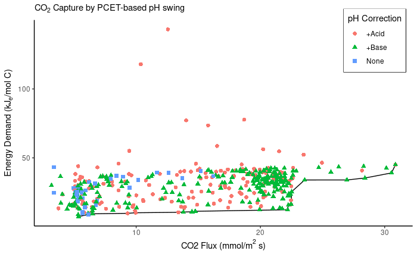

```r
# Load dataset
GPar.all = read.csv(file = 'GPar_AcidBase_data.csv')
GPar.front = read.csv(file = 'GPar_AcidBase_fnt.csv')
# Remove unneeded variables
GPar.all = GPar.all[,!(names(GPar.all) %in% c('X', 'X.1'))]
GPar.front = GPar.front[,!(names(GPar.front) %in% c('X', 'X.1'))]

# Natural variables conversion
GPar.nat = GPar.all
GPar.nat$pka2 = GPar.nat$pka1 + GPar.nat$pka2
GPar.nat$Na.A = GPar.nat$logA + GPar.nat$Na.A

# For acid/base, low additions (<10^-7) are effectively no additions
GPar.nat$typ.none = GPar.nat$typ
GPar.nat$typ.none[GPar.nat$Na.A < -7] = 'None'

sz = 2
ggplot(filter(GPar.nat, Energy.kJ.mol < 150, Flux.mol.m2s > 0)) +
  geom_line(GPar.front, mapping = aes(x = Flux.mol.m2s*1e3, y = Energy.kJ.mol), color = 'black') +
  geom_point(mapping = aes(x = Flux.mol.m2s*1e3, y = Energy.kJ.mol, color = typ.none, shape = typ.none), size = sz) +
  labs(x = expression('CO2 Flux (mmol/m'^2*' s)'), y = expression('Energy Demand (kJ'['e']*'/mol C)'),
       subtitle = expression('CO'[2]*' Capture by PCET-based pH swing'), color = 'pH Correction', shape = 'pH Correction') +
  theme_classic() + theme(legend.position = c(0.9, 0.9),
                          legend.box.background = element_rect(color = 'black', linetype = 1))
```

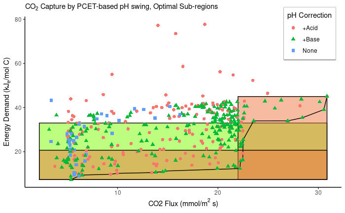

```r
# Regions of interest
# Region 1: acceptable results: based on MEA
reg.full = data.frame(min.flux = 2.2e-3,
                     max.flux = max(GPar.front$Flux.mol.m2s),
                     min.ener = min(GPar.front$Energy.kJ.mol), max.ener = 33)
# Region 2: the right-hand side of high flux but moderate energy, i.e. flux > 22 mmol/m2s. Increase the energy above 45 to capture the Pareto front there
reg.flux = data.frame(min.flux = 22e-3, max.flux = max(GPar.front$Flux.mol.m2s),
                     min.ener = min(GPar.front$Energy.kJ.mol),
                     max.ener = 45)
# Region 3: the bottom section of low energy but moderate flux
reg.ener = data.frame(min.flux = 2.2e-3,
                     max.flux = max(GPar.front$Flux.mol.m2s),
                     min.ener = min(GPar.front$Energy.kJ.mol),
                     max.ener = mean(range(filter(GPar.front, Flux.mol.m2s < 24e-3)$Energy.kJ.mol)))
# Plotting
ggplot() +
  geom_rect(reg.full,
            mapping = aes(xmin = min.flux*1e3, xmax = max.flux*1e3, ymin = min.ener, ymax = max.ener),
            fill = 'lawngreen', linetype = 1, color = 'black', alpha = 0.5) +
  geom_rect(rbind(reg.flux, reg.ener),
            mapping = aes(xmin = min.flux*1e3, xmax = max.flux*1e3, ymin = min.ener, ymax = max.ener),
            fill = 'sienna2', linetype = 1, color = 'black', alpha = 0.5) +
  geom_line(GPar.front,
            mapping = aes(x = Flux.mol.m2s*1e3, y = Energy.kJ.mol), color = 'black') +
  geom_point(filter(GPar.nat, Energy.kJ.mol < 100, Flux.mol.m2s > 0),
             mapping = aes(x = Flux.mol.m2s*1e3, y = Energy.kJ.mol, color = typ.none, shape = typ.none),
             size = sz) +
  labs(x = expression('CO2 Flux (mmol/m'^2*' s)'), y = expression('Energy Demand (kJ'['e']*'/mol C)'),
       subtitle = expression('CO'[2]*' Capture by PCET-based pH swing, Optimal Sub-regions'),
       color = 'pH Correction', shape = 'pH Correction') +
  theme_classic() + theme(legend.position = c(0.9, 0.9),
                          legend.box.background = element_rect(color = 'black', linetype = 1))
```

```r
GPar.nat = GPar.nat[,!(names(GPar.nat) %in% c('typ.none'))]

# Need to use the acid/base conditions as numeric variable, not categorical variable for the GP
typ = rep(0, nrow(GPar.nat))
typ[GPar.nat$typ == '+Acid'] = -1
typ[GPar.nat$typ == '+Base'] = +1
GPar.nat$typ = typ
```

The Pareto front has a slight concavity where the energy demand increases but the flux remains constant; coincidentally, this happens at around the flux of MEA capture. This line delineates two regions of interest: a set of options for low energy demands at viable fluxes and a set of options for high flux at viable energy demands.

# GP Model setup

Partial data cleaning may be needed: there are samples where the flux is very strongly negative (less than -10 mol/m2s), which sometimes skews the results. However, the flux cannot be converted to a log scale as the energy was because it contains fluxes at or around 0. Instead, a partial sample of points will be used to generate a collection of models, whose average performance will be used as the estimate. This was also some inconsistency between runs due to slight differences in the random number seed, suggesting either poor convergence or degeneracy of the GP models. Regardless, aggregation of multiple models trained on subsets of the data should help make results more consistent.

In this case, the mean probability and standard error of the mean will be used as the metrics for importance ranking, as well as for determining suggested ranges. This repeated testing should minimize the run-to-run variance in the probability estimations.

Adequate sampling requires at least 60% of the dataset, as this guarantees that at least some of the points in the training set have positive fluxes and/or low energy demands.

Combining the acid and base datasets leads to convergence issues even if a fifth variable of whether acid or base is included in the model. As a result, half of the models will be generated with acid conditions and half with basic conditions, and they will handled separated until aggregation of the probabilities at the end.

There is interest in obtaining not just the parameters for the natural variables, but also for the relative variables (pKa difference and acid or base to quinone ratio), as those may be more insightful.

```r
# Generate multiple models for each output variable
nmod = 5
mod.flux.a = list(); mod.ener.a = list()
mod.flux.b = list(); mod.ener.b = list()
mod.flux.a.rel = list(); mod.ener.a.rel = list()
mod.flux.b.rel = list(); mod.ener.b.rel = list()

row.frac = 0.6
# row.frac = 1
for(i in 1:nmod){
  # Base: natural variables
  GPar.samp = filter(GPar.nat, typ == 1)
  nsamp = ceiling(nrow(GPar.samp)*row.frac)
  GPar.samp = GPar.samp[sample(x = 1:nrow(GPar.samp), size = nsamp), ]
  mod = fill.sample.flux(GPar.data = GPar.samp, input.name = c('pka1', 'pka2', 'logA', 'Na.A'),
                             output.name = 'Flux.mol.m2s')
  mod.flux.b = append(mod.flux.b, mod)
  mod = fill.sample.ener(GPar.data = GPar.samp,
                              input.name = c('pka1', 'pka2', 'logA', 'Na.A'),
                              output.name = 'Energy.kJ.mol')
  mod.ener.b = append(mod.ener.b, mod)
  # Acid: natural variables
  GPar.samp = filter(GPar.nat, typ == -1)
  nsamp = ceiling(nrow(GPar.samp)*row.frac)
  GPar.samp = GPar.samp[sample(x = 1:nrow(GPar.samp), size = nsamp), ]
  mod = fill.sample.flux(GPar.data = GPar.samp, input.name = c('pka1', 'pka2', 'logA', 'Na.A'),
                             output.name = 'Flux.mol.m2s')
  mod.flux.a = append(mod.flux.a, mod)
  mod = fill.sample.ener(GPar.data = GPar.samp,
                              input.name = c('pka1', 'pka2', 'logA', 'Na.A'),
                              output.name = 'Energy.kJ.mol')
  mod.ener.a = append(mod.ener.a, mod)

  # Base: relative variables
  GPar.samp = filter(GPar.all, typ == '+Base')
  nsamp = ceiling(nrow(GPar.samp)*row.frac)
  GPar.samp = GPar.samp[sample(x = 1:nrow(GPar.samp), size = nsamp), ]
  mod = fill.sample.flux(GPar.data = GPar.samp, input.name = c('pka1', 'pka2', 'logA', 'Na.A'),
                             output.name = 'Flux.mol.m2s')
  mod.flux.b.rel = append(mod.flux.b.rel, mod)
  mod = fill.sample.ener(GPar.data = GPar.samp,
                              input.name = c('pka1', 'pka2', 'logA', 'Na.A'),
                              output.name = 'Energy.kJ.mol')
  mod.ener.b.rel = append(mod.ener.b.rel, mod)
  # Acid: relative variables
  GPar.samp = filter(GPar.all, typ == '+Acid')
  nsamp = ceiling(nrow(GPar.samp)*row.frac)
  GPar.samp = GPar.samp[sample(x = 1:nrow(GPar.samp), size = nsamp), ]
  mod = fill.sample.flux(GPar.data = GPar.samp, input.name = c('pka1', 'pka2', 'logA', 'Na.A'),
                             output.name = 'Flux.mol.m2s')
  mod.flux.a.rel = append(mod.flux.a.rel, mod)
  mod = fill.sample.ener(GPar.data = GPar.samp,
                              input.name = c('pka1', 'pka2', 'logA', 'Na.A'),
                              output.name = 'Energy.kJ.mol')
  mod.ener.a.rel = append(mod.ener.a.rel, mod)
}

rm(nmod, mod, nsamp, GPar.samp)
```

# Output space characterization

How likely a randomly selected set of inputs will generate good or bad results? What the average result would be? What is the range of possible results? This will be assessed using the relative variable functions since they are easier to sample from (rectangular constraints), and the quality difference among the GP with initial testing did not appear to be substantially different. These questions will be answered using the means among the different GP trained on different subsets, with the belief that the average among them will converge on the true expected mean.

That is, for a randomly sampled point, for each model: * Determine its energy and flux * Determine its probability of being competitive with MEA, high flux, or low energy This will generate a mean and variance for each point, which, with repeated sampling, can give a sense of the entire space.

```r
# Create a set of random points based on the limits
MCsamp = 5e4
rand.samp = data.frame(pka1 = runif(n = MCsamp, min = min(GPar.all$pka1), max = max(GPar.all$pka1)),
                       pka2 = runif(n = MCsamp, min = min(GPar.all$pka2), max = max(GPar.all$pka2)),
                       logA = runif(n = MCsamp, min = min(GPar.all$logA), max = max(GPar.all$logA)),
                       Na.A = runif(n = MCsamp, min = min(GPar.all$Na.A), max = max(GPar.all$Na.A)))
# Mean and ranges
ener = matrix(rep(0, 2*length(mod.ener.a.rel)*nrow(rand.samp)), nrow = nrow(rand.samp))
flux = ener
# Probabilities: competitive with MEA, low energy, high flux, and at least 90% capture
p.acpt = ener; p.ener = ener; p.flux = ener; p.capt = ener;
# Probabilities

for(i in 1:length(mod.ener.a.rel)){
  # Energies
  fill.e = predict(mod.ener.a.rel[[i]], newdata = rand.samp, type = 'UK')
  ener[,i] = fill.e$mean
  # Fluxes
  fill.f = predict(mod.flux.a.rel[[i]], newdata = rand.samp, type = 'UK')
  flux[,i] = fill.f$mean
  # Probabilities
  p.acpt[,i] = (1 - pnorm(q = 0, mean = fill.f$mean - reg.full$min.flux, sd = fill.f$sd)) *
        pnorm(q = 0, mean = fill.e$mean - log10(reg.full$max.ener), sd = fill.e$sd)
  p.ener[,i] = (1 - pnorm(q = 0, mean = fill.f$mean - reg.ener$min.flux, sd = fill.f$sd)) *
        pnorm(q = 0, mean = fill.e$mean - log10(reg.ener$max.ener), sd = fill.e$sd)
  p.flux[,i] = (1 - pnorm(q = 0, mean = fill.f$mean - reg.flux$min.flux, sd = fill.f$sd)) *
        pnorm(q = 0, mean = fill.e$mean - log10(reg.flux$max.ener), sd = fill.e$sd)
  p.capt[,i] = (1 - pnorm(q = 0, mean = fill.f$mean, sd = fill.f$sd))
  # Repeat with base
  fill.e = predict(mod.ener.b.rel[[i]], newdata = rand.samp, type = 'UK')
  ener[,i+length(mod.ener.a.rel)] = fill.e$mean
  fill.f = predict(mod.flux.b.rel[[i]], newdata = rand.samp, type = 'UK')
  flux[,i+length(mod.ener.a.rel)] = fill.f$mean
  p.acpt[,i+length(mod.ener.a.rel)] =
    (1 - pnorm(q = 0, mean = fill.f$mean - reg.full$min.flux, sd = fill.f$sd)) *
        pnorm(q = 0, mean = fill.e$mean - log10(reg.full$max.ener), sd = fill.e$sd)
  p.ener[,i+length(mod.ener.a.rel)] =
    (1 - pnorm(q = 0, mean = fill.f$mean - reg.ener$min.flux, sd = fill.f$sd)) *
        pnorm(q = 0, mean = fill.e$mean - log10(reg.ener$max.ener), sd = fill.e$sd)
  p.flux[,i+length(mod.ener.a.rel)] =
    (1 - pnorm(q = 0, mean = fill.f$mean - reg.flux$min.flux, sd = fill.f$sd)) *
        pnorm(q = 0, mean = fill.e$mean - log10(reg.flux$max.ener), sd = fill.e$sd)
  p.capt[,i+length(mod.ener.a.rel)] =
    (1 - pnorm(q = 0, mean = fill.f$mean, sd = fill.f$sd))
}
rm(fill.e, fill.f)
# Set of possible energies and fluxes
rand.samp$ener = 10^apply(ener, 1, mean)
rand.samp$flux = apply(flux, 1, mean)
rand.samp$p.acpt = apply(p.acpt, 1, mean)
rand.samp$p.ener = apply(p.ener, 1, mean)
rand.samp$p.flux = apply(p.flux, 1, mean)
rand.samp$p.capt = apply(p.capt, 1, mean)
rm(ener, flux, p.acpt, p.ener, p.flux, p.capt)
# Mean energy
descr = rbind(apply(as.matrix(rand.samp), 2, range),
      apply(as.matrix(rand.samp), 2, mean),
      apply(as.matrix(rand.samp), 2, sd),
      apply(as.matrix(rand.samp), 2, median))
descr = descr[, 5:ncol(descr)]
row.names(descr) = c('Min', 'Max', 'Mean', 'SD', 'Median')
descr
```

```
              ener         flux       p.acpt       p.ener       p.flux       p.capt
Min        8.19195 -0.021151262 3.260318e-28 9.728261e-31 0.000000e+00 2.196359e-08
Max    10782.89996  0.030209478 9.294246e-01 8.384352e-01 6.726428e-01 1.000000e+00
Mean     311.71931  0.004705753 2.704424e-01 1.884121e-01 1.174806e-02 7.635299e-01
SD       670.01187  0.007026204 2.329577e-01 1.738483e-01 6.398968e-02 2.909892e-01
Median    73.72569  0.004819689 2.870670e-01 1.828655e-01 1.955208e-06 9.236382e-01
```

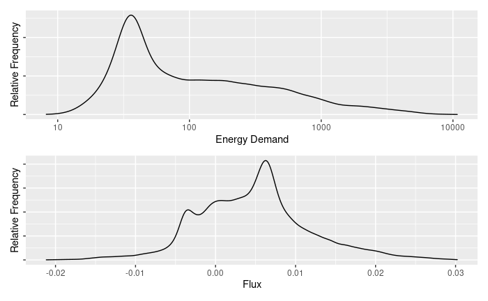

```r
g1 = ggplot(rand.samp) +
  geom_density(mapping = aes(x = ener)) +
  labs(x = 'Energy Demand', y = 'Relative Frequency') +
  scale_y_continuous(labels = NULL) +
  scale_x_log10()
g2 = ggplot(rand.samp) +
  geom_density(mapping = aes(x = flux)) +
  labs(x = 'Flux', y = 'Relative Frequency') +
  scale_y_continuous(labels = NULL)
g1 / g2
```

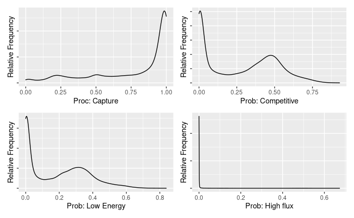

```r
g1 = ggplot(rand.samp) +
  geom_density(mapping = aes(x = p.capt)) +
  labs(x = 'Proc: Capture', y = 'Relative Frequency') +
  scale_y_continuous(labels = NULL)
g2 = ggplot(rand.samp) +
  geom_density(mapping = aes(x = p.acpt)) +
  labs(x = 'Prob: Competitive', y = 'Relative Frequency') +
  scale_y_continuous(labels = NULL)
g3 = ggplot(rand.samp) +
  geom_density(mapping = aes(x = p.ener)) +
  labs(x = 'Prob: Low Energy', y = 'Relative Frequency') +
  scale_y_continuous(labels = NULL)
g4 = ggplot(rand.samp) +
  geom_density(mapping = aes(x = p.flux)) +
  labs(x = 'Prob: High flux', y = 'Relative Frequency') +
  scale_y_continuous(labels = NULL)
(g1 + g2) / (g3 + g4)
```

```r
rm(g1, g2, g3, g4)

write.csv(rand.samp[, names(rand.samp) %in% c('ener', 'flux')], 'OutcomeDistribution.csv')
write.csv(descr, 'OutcomeDescribe.csv')
rm(rand.samp, descr)
```

The distributions for the energy demand and flux appear don’t capture the entire range of possibilities from the training dataset: the flux does not extend as low (approximately -10 on this scale), while the energy demand does not extend as high (10^7). This suggests that the distributions are more centrally-focused, or that those extrema were rare events found by exploratory sampling. This does, however, provide some indication regarding the relative distributions close to the modal value: the energy demand tends to be focused in the 30-100 kJ/mol range, while the flux tends to be slightly positive.

Looking at the relative frequencies of the sampled probabilities, there is some interesting multimodality in all distributions except the high flux condition. This suggests that there are clusters of points that are likely to meet the specified criteria, and another cluster of points that are less likely.

# Importance Rankings

Assessment of the importance ranking of the 5 variables (pka1, pka2, concentration of quinone, concentration of pH correction species, and decision of acid or base)

For the importance ranking, the most importance has the lowest total variance, normalized by the range of the mean probabilities (i.e. high variance with low means will be least important). We use the average variance to be able to compare continuous variables to categorical variables.

The ranking can vary based on the specific region of interest, so each region (generally acceptable, high flux, and low energy) will be assessed separately. Uncertainty estimate of the ranking uses the standard propagation of uncertainty for a function defined by $f(x) = 1/x$ where $x$ has known variance ($s_x$).

For ease of repeatability, writing a set of functions.

```r
marginals1D = function(E.cutof, F.cutof, mod.flux.a, mod.ener.a, mod.flux.b, mod.ener.b){
  # Cutoff values should be converted based on the model conversions to log units
  E.cutof = log10(E.cutof)
  # F.cutof = F.cutof
  # Constants
  resolution = 50; MCsamp = 1000
  pka1.rng = c(2, 13.5); pka2.rng = c(0, 5.5)
  logA.rng = c(-2, 0.5); Na.A.rng = c(-7, 0.7)

  # Dataframe storage
  post.optim = data.frame(pka1 = seq(from = pka1.rng[1], to = pka1.rng[2], length.out = resolution),
                          pka2 = seq(from = pka2.rng[1] + pka1.rng[1], to = pka2.rng[2] + pka1.rng[2],
                                     length.out = resolution),
                          logA = seq(from = logA.rng[1], to = logA.rng[2], length.out = resolution),
                          Na.A = seq(from = Na.A.rng[1] + logA.rng[1], to = Na.A.rng[2] + logA.rng[2],
                                     length.out = resolution),
          # Combined acid and base for importance ranking
          p.pka1 = NaN, p.pka2 = NaN, p.logA = NaN, p.Na.A = NaN, # Probability acceptance median
          s.pka1 = NaN, s.pka2 = NaN, s.logA = NaN, s.Na.A = NaN, # variance for importance ranking
          # Acid and base separated for marginalization plotting
          pa.pka1 = NaN, pa.pka2 = NaN, pa.logA = NaN, pa.Na.A = NaN, # Probability acceptance median
          sa.pka1 = NaN, sa.pka2 = NaN, sa.logA = NaN, sa.Na.A = NaN, # variance for importance ranking
          pb.pka1 = NaN, pb.pka2 = NaN, pb.logA = NaN, pb.Na.A = NaN, # Probability acceptance median
          sb.pka1 = NaN, sb.pka2 = NaN, sb.logA = NaN, sb.Na.A = NaN, # variance for importance ranking
          sd.pka1 = NaN, sd.pka2 = NaN, sd.logA = NaN, sd.Na.A = NaN) # importance ranking uncertainty

  # Monte Carlo loop
  for(i in 1:resolution){
    # pka1
    fill.frame = data.frame(pka1 = post.optim$pka1[i],
                            pka2 = runif(n = MCsamp, min = pka2.rng[1], max = pka2.rng[2]) + post.optim$pka1[i],
                            logA = runif(n = MCsamp, min = logA.rng[1], max = logA.rng[2]),
                            Na.A = runif(n = MCsamp, min = Na.A.rng[1], max = Na.A.rng[2]))
    fill.frame$Na.A = fill.frame$logA + fill.frame$Na.A
    set.flux = sample(1:length(mod.flux.a), length(mod.flux.a))
    set.ener = sample(1:length(mod.flux.a), length(mod.flux.a))
    p.a = c(); s.a = c(); p.b = c(); s.b = c();
    for(j in 1:length(set.flux)){
      # For the purposes of combining systems, only use the same acid/base condition
      res.flux = predict(object = mod.flux.a[[set.flux[j]]], newdata = fill.frame, type = 'UK')
      res.ener = predict(object = mod.ener.a[[set.ener[j]]], newdata = fill.frame, type = 'UK')
      p.accept = (1 - pnorm(q = 0, mean = res.flux$mean - F.cutof, sd = res.flux$sd)) *
        pnorm(q = 0, mean = res.ener$mean - E.cutof, sd = res.ener$sd)
      p.a[j] = mean(p.accept)
      s.a[j] = sd(p.accept)
      # Base
      res.flux = predict(object = mod.flux.b[[set.flux[j]]], newdata = fill.frame, type = 'UK')
      res.ener = predict(object = mod.ener.b[[set.ener[j]]], newdata = fill.frame, type = 'UK')
      p.accept = (1 - pnorm(q = 0, mean = res.flux$mean - F.cutof, sd = res.flux$sd)) *
        pnorm(q = 0, mean = res.ener$mean - E.cutof, sd = res.ener$sd)
      p.b[j] = mean(p.accept)
      s.b[j] = sd(p.accept)
    }
    # Acid/base for marginal
    post.optim$pa.pka1[i] = mean(p.a);  post.optim$pb.pka1[i] = mean(p.b)
    post.optim$sa.pka1[i] = sd(p.a);  post.optim$sb.pka1[i] = sd(p.b)
    post.optim$p.pka1[i] = mean(c(p.a, p.b));
    post.optim$s.pka1[i] = sqrt(mean(c(s.a, s.b)^2)); # Average Variance, not average standard deviation
    post.optim$sd.pka1[i] = sd(c(s.a, s.b)) # Variance of the variance for importance ranking uncertainty

    # pka2
    # Define the min/max
    pka1.testrng = c(max(pka1.rng[1], post.optim$pka2[i] - pka2.rng[2]),
                     min(pka1.rng[2], post.optim$pka2[i] - pka2.rng[1]))

    fill.frame = data.frame(pka2 = post.optim$pka2[i],
                            pka1 = runif(n = MCsamp, min = pka1.testrng[1], max = pka1.testrng[2]),
                            logA = runif(n = MCsamp, min = logA.rng[1], max = logA.rng[2]),
                            Na.A = runif(n = MCsamp, min = Na.A.rng[1], max = Na.A.rng[2]))
    fill.frame$Na.A = fill.frame$logA + fill.frame$Na.A
    p.a = c(); s.a = c(); p.b = c(); s.b = c();
    for(j in 1:length(set.flux)){
      # For the purposes of combining systems, only use the same acid/base condition
      res.flux = predict(object = mod.flux.a[[set.flux[j]]], newdata = fill.frame, type = 'UK')
      res.ener = predict(object = mod.ener.a[[set.ener[j]]], newdata = fill.frame, type = 'UK')
      p.accept = (1 - pnorm(q = 0, mean = res.flux$mean - F.cutof, sd = res.flux$sd)) *
        pnorm(q = 0, mean = res.ener$mean - E.cutof, sd = res.ener$sd)
      p.a[j] = mean(p.accept)
      s.a[j] = sd(p.accept)
      # Base
      res.flux = predict(object = mod.flux.b[[set.flux[j]]], newdata = fill.frame, type = 'UK')
      res.ener = predict(object = mod.ener.b[[set.ener[j]]], newdata = fill.frame, type = 'UK')
      p.accept = (1 - pnorm(q = 0, mean = res.flux$mean - F.cutof, sd = res.flux$sd)) *
        pnorm(q = 0, mean = res.ener$mean - E.cutof, sd = res.ener$sd)
      p.b[j] = mean(p.accept)
      s.b[j] = sd(p.accept)
    }
    # Acid/base for marginal
    post.optim$pa.pka2[i] = mean(p.a);  post.optim$pb.pka2[i] = mean(p.b)
    post.optim$sa.pka2[i] = sd(p.a);  post.optim$sb.pka2[i] = sd(p.b)
    post.optim$p.pka2[i] = mean(c(p.a, p.b));
    post.optim$s.pka2[i] = sqrt(mean(c(s.a, s.b)^2));
    post.optim$sd.pka2[i] = sd(c(s.a, s.b))

    # log Quinone
    fill.frame = data.frame(logA = post.optim$logA[i],
                            pka1 = runif(n = MCsamp, min = pka1.rng[1], max = pka1.rng[2]),
                            pka2 = runif(n = MCsamp, min = pka2.rng[1], max = pka2.rng[2]),
                            Na.A = runif(n = MCsamp, min = Na.A.rng[1], max = Na.A.rng[2]))
    fill.frame$pka2 = fill.frame$pka1 + fill.frame$pka2
    fill.frame$Na.A = fill.frame$logA + fill.frame$Na.A
    p.a = c(); s.a = c(); p.b = c(); s.b = c();
    for(j in 1:length(set.flux)){
      # For the purposes of combining systems, only use the same acid/base condition
      res.flux = predict(object = mod.flux.a[[set.flux[j]]], newdata = fill.frame, type = 'UK')
      res.ener = predict(object = mod.ener.a[[set.ener[j]]], newdata = fill.frame, type = 'UK')
      p.accept = (1 - pnorm(q = 0, mean = res.flux$mean - F.cutof, sd = res.flux$sd)) *
        pnorm(q = 0, mean = res.ener$mean - E.cutof, sd = res.ener$sd)
      p.a[j] = mean(p.accept)
      s.a[j] = sd(p.accept)
      # Base
      res.flux = predict(object = mod.flux.b[[set.flux[j]]], newdata = fill.frame, type = 'UK')
      res.ener = predict(object = mod.ener.b[[set.ener[j]]], newdata = fill.frame, type = 'UK')
      p.accept = (1 - pnorm(q = 0, mean = res.flux$mean - F.cutof, sd = res.flux$sd)) *
        pnorm(q = 0, mean = res.ener$mean - E.cutof, sd = res.ener$sd)
      p.b[j] = mean(p.accept)
      s.b[j] = sd(p.accept)
    }
    # Acid/base for marginal
    post.optim$pa.logA[i] = mean(p.a);  post.optim$pb.logA[i] = mean(p.b)
    post.optim$sa.logA[i] = sd(p.a);  post.optim$sb.logA[i] = sd(p.b)
    post.optim$p.logA[i] = mean(c(p.a, p.b));
    post.optim$s.logA[i] = sqrt(mean(c(s.a, s.b)^2));
    post.optim$sd.logA[i] = sd(c(s.a, s.b))
```

```r
    # Na/A
    logA.testrng = c(max(logA.rng[1], post.optim$Na.A[i] - Na.A.rng[2]),
                     min(logA.rng[2], post.optim$Na.A[i] - Na.A.rng[1]))

    fill.frame = data.frame(Na.A = post.optim$Na.A[i],
                            pka1 = runif(n = MCsamp, min = pka1.rng[1], max = pka1.rng[2]),
                            pka2 = runif(n = MCsamp, min = pka2.rng[1], max = pka2.rng[2]),
                            logA = runif(n = MCsamp, min = logA.testrng[1], max = logA.testrng[2]))
    fill.frame$pka2 = fill.frame$pka1 + fill.frame$pka2
    p.a = c(); s.a = c(); p.b = c(); s.b = c();
    for(j in 1:length(set.flux)){
      # For the purposes of combining systems, only use the same acid/base condition
      res.flux = predict(object = mod.flux.a[[set.flux[j]]], newdata = fill.frame, type = 'UK')
      res.ener = predict(object = mod.ener.a[[set.ener[j]]], newdata = fill.frame, type = 'UK')
      p.accept = (1 - pnorm(q = 0, mean = res.flux$mean - F.cutof, sd = res.flux$sd)) *
        pnorm(q = 0, mean = res.ener$mean - E.cutof, sd = res.ener$sd)
      p.a[j] = mean(p.accept)
      s.a[j] = sd(p.accept)
      # Base
      res.flux = predict(object = mod.flux.b[[set.flux[j]]], newdata = fill.frame, type = 'UK')
      res.ener = predict(object = mod.ener.b[[set.ener[j]]], newdata = fill.frame, type = 'UK')
      p.accept = (1 - pnorm(q = 0, mean = res.flux$mean - F.cutof, sd = res.flux$sd)) *
        pnorm(q = 0, mean = res.ener$mean - E.cutof, sd = res.ener$sd)
      p.b[j] = mean(p.accept)
      s.b[j] = sd(p.accept)
    }
    # Acid/base for marginal
    post.optim$pa.Na.A[i] = mean(p.a);  post.optim$pb.Na.A[i] = mean(p.b)
    post.optim$sa.Na.A[i] = sd(p.a);  post.optim$sb.Na.A[i] = sd(p.b)
    post.optim$p.Na.A[i] = mean(c(p.a, p.b));
    post.optim$s.Na.A[i] = sqrt(mean(c(s.a, s.b)^2));
    post.optim$sd.Na.A[i] = sd(c(s.a, s.b))
  }

  # Acid/base determination
  typ = c(-1, +1);
  fill.frame = data.frame(pka1 = runif(n = MCsamp, min = pka1.rng[1], max = pka1.rng[2]),
                          pka2 = runif(n = MCsamp, min = pka2.rng[1], max = pka2.rng[2]),
                          logA = runif(n = MCsamp, min = logA.rng[1], max = logA.rng[2]),
                          Na.A = runif(n = MCsamp, min = Na.A.rng[1], max = Na.A.rng[2]))
  fill.frame$Na.A = fill.frame$logA + fill.frame$Na.A
  fill.frame$pka2 = fill.frame$pka1 + fill.frame$pka2
  set.flux = sample(1:length(mod.flux.a), length(mod.flux.a))
  set.ener = sample(1:length(mod.ener.a), length(mod.ener.a))
  p.a = c(); s.a = c(); p.b = c(); s.b = c()
  for(j in 1:length(set.flux)){
    res.flux = predict(object = mod.flux.a[[set.flux[j]]], newdata = fill.frame, type = 'UK')
    res.ener = predict(object = mod.ener.a[[set.ener[j]]], newdata = fill.frame, type = 'UK')
    p.accept = (1 - pnorm(q = 0, mean = res.flux$mean - F.cutof, sd = res.flux$sd)) *
      pnorm(q = 0, mean = res.ener$mean - E.cutof, sd = res.ener$sd)
    p.a[j] = mean(p.accept)
    s.a[j] = sd(p.accept)
    res.flux = predict(object = mod.flux.b[[set.flux[j]]], newdata = fill.frame, type = 'UK')
    res.ener = predict(object = mod.ener.b[[set.ener[j]]], newdata = fill.frame, type = 'UK')
    p.accept = (1 - pnorm(q = 0, mean = res.flux$mean - F.cutof, sd = res.flux$sd)) *
      pnorm(q = 0, mean = res.ener$mean - E.cutof, sd = res.ener$sd)
    p.b[j] = mean(p.accept)
    s.b[j] = sd(p.accept)
  }
  post.opt.typ = data.frame(typ = typ,
                            p = c(mean(p.a), mean(p.b)),
                            s = c(sqrt(mean(s.a^2)), sqrt(mean(s.b^2))),
                            sd = c(sd(s.a), sd(s.b)) )
  # For plotting, probability is bounded [0, 1]
  # pka1
  post.optim$l.pka1 = post.optim$p.pka1 - post.optim$s.pka1
  post.optim$l.pka1[post.optim$l.pka1 < 0] = 0
  post.optim$h.pka1 = post.optim$p.pka1 + post.optim$s.pka1
  post.optim$h.pka1[post.optim$h.pka1 > 1] = 1
  # pka2
  post.optim$l.pka2 = post.optim$p.pka2 - post.optim$s.pka2
  post.optim$l.pka2[post.optim$l.pka2 < 0] = 0
  post.optim$h.pka2 = post.optim$p.pka2 + post.optim$s.pka2
  post.optim$h.pka2[post.optim$h.pka2 > 1] = 1
  # logA
  post.optim$l.logA = post.optim$p.logA - post.optim$s.logA
  post.optim$l.logA[post.optim$l.logA < 0] = 0
  post.optim$h.logA = post.optim$p.logA + post.optim$s.logA
  post.optim$h.logA[post.optim$h.logA > 1] = 1
  # Na.A
  post.optim$l.Na.A = post.optim$p.Na.A - post.optim$s.Na.A
  post.optim$l.Na.A[post.optim$l.Na.A < 0] = 0
  post.optim$h.Na.A = post.optim$p.Na.A + post.optim$s.Na.A
  post.optim$h.Na.A[post.optim$h.Na.A > 1] = 1
  # Acid/Base
  post.opt.typ$l = post.opt.typ$p - post.opt.typ$s
  post.opt.typ$l[post.opt.typ$l < 0] = 0
  post.opt.typ$h = post.opt.typ$p + post.opt.typ$s
  post.opt.typ$h[post.opt.typ$h > 1] = 1

  return(list(var = post.optim, base = post.opt.typ))
}

# Take the marginals
import.rank = function(post.optim, post.opt.typ){
  # Calculating the rankings
  # Higher variance = other variables are more important (inverse of variance = more important control variable)
  # Greater range of probabilities = more important
  import = data.frame(rng = c(diff(range(post.optim$p.pka1)), diff(range(post.optim$p.pka2)),
                              diff(range(post.optim$p.logA)), diff(range(post.optim$p.Na.A))),
                      area = c(sum(post.optim$s.pka1), sum(post.optim$s.pka2),
                               sum(post.optim$s.logA), sum(post.optim$s.Na.A)),
                      var = c('pka1', 'pka2', 'logA', 'Na.A'),
                      sd = c(sum(post.optim$sd.pka1), sum(post.optim$sd.pka2),
                             sum(post.optim$sd.logA), sum(post.optim$sd.Na.A)))
  import$rank = import$rng/import$area
  import$uncert = import$rank*import$sd/import$area

  import.all = data.frame(rng = diff(range(post.opt.typ$p)),
                          area = sum(post.opt.typ$s), var = 'Base',
                          sd = sum(post.opt.typ$sd))
  import.all$rank = import.all$rng/(import.all$area * nrow(post.optim) / nrow(post.opt.typ))
  import.all$uncert = import.all$rank*import.all$sd/import.all$area
  import.all = rbind(import, import.all)
  return(import.all)
}
```

```r
# Run function: 1D marginals
margin.reg1 = marginals1D(E.cutof = reg.full$max.ener, F.cutof = reg.full$min.flux,
            mod.flux.a, mod.ener.a, mod.flux.b, mod.ener.b)
margin.reg2 = marginals1D(E.cutof = reg.flux$max.ener, F.cutof = reg.flux$min.flux,
            mod.flux.a, mod.ener.a, mod.flux.b, mod.ener.b)
margin.reg3 = marginals1D(E.cutof = reg.ener$max.ener, F.cutof = reg.ener$min.flux,
            mod.flux.a, mod.ener.a, mod.flux.b, mod.ener.b)
# Run function: importance rank
import.reg1 = import.rank(post.optim = margin.reg1$var, post.opt.typ = margin.reg1$base)
import.reg2 = import.rank(post.optim = margin.reg2$var, post.opt.typ = margin.reg2$base)
import.reg3 = import.rank(post.optim = margin.reg3$var, post.opt.typ = margin.reg3$base)

# Store information so it does not have to be run again
margin.reg1$var$region = 'Full Viable Region'
margin.reg2$var$region = 'Maximum Flux'
margin.reg3$var$region = 'Minimum Energy'
write.csv(rbind(margin.reg1$var, margin.reg2$var, margin.reg3$var), '1DMarginals.csv')

margin.reg1$base$region = 'Full Viable Region'
margin.reg2$base$region = 'Maximum Flux'
margin.reg3$base$region = 'Minimum Energy'
write.csv(rbind(margin.reg1$base, margin.reg2$base, margin.reg3$base), 'AcidBaseMarginal.csv')

import.reg1$region = 'Full Viable Region'
import.reg2$region = 'Maximum Flux'
import.reg3$region = 'Minimum Energy'
write.csv(rbind(import.reg1, import.reg2, import.reg3), 'ImportanceRanking.csv')
```

```r
marg = read.csv('1DMarginals.csv')
base = read.csv('AcidBaseMarginal.csv')
impo = read.csv('ImportanceRanking.csv')

margin.reg1 = list(var = filter(marg, region == 'Full Viable Region'),
                   base = filter(base, region == 'Full Viable Region'))
margin.reg2 = list(var = filter(marg, region == 'Maximum Flux'),
                   base = filter(base, region == 'Maximum Flux'))
margin.reg3 = list(var = filter(marg, region == 'Minimum Energy'),
                   base = filter(base, region == 'Minimum Energy'))
import.reg1 = filter(impo, region == 'Full Viable Region')
import.reg2 = filter(impo, region == 'Maximum Flux')
import.reg3 = filter(impo, region == 'Minimum Energy')
```

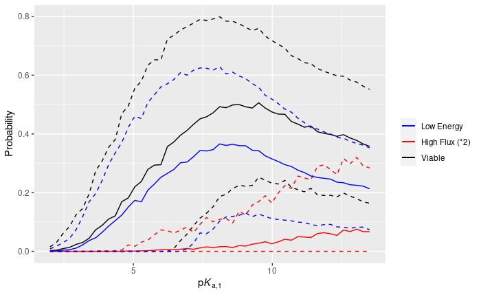

```r
ggplot() +
  # Full region
  geom_path(data = margin.reg1$var, mapping = aes(x = pka1, y = l.pka1, color = 'Full'), linetype = 2) +
  geom_path(data = margin.reg1$var, mapping = aes(x = pka1, y = h.pka1, color = 'Full'), linetype = 2) +
  geom_path(data = margin.reg1$var, mapping = aes(x = pka1, y = p.pka1, color = 'Full')) +
  # High flux region
  geom_path(data = margin.reg2$var, mapping = aes(x = pka1, y = l.pka1*2, color = 'Flux'), linetype = 2) +
  geom_path(data = margin.reg2$var, mapping = aes(x = pka1, y = h.pka1*2, color = 'Flux'), linetype = 2) +
  geom_path(data = margin.reg2$var, mapping = aes(x = pka1, y = p.pka1*2, color = 'Flux')) +
  # Low Energy region
  geom_path(data = margin.reg3$var, mapping = aes(x = pka1, y = l.pka1, color = 'Ener'), linetype = 2) +
  geom_path(data = margin.reg3$var, mapping = aes(x = pka1, y = h.pka1, color = 'Ener'), linetype = 2) +
  geom_path(data = margin.reg3$var, mapping = aes(x = pka1, y = p.pka1, color = 'Ener')) +
  labs(x = expression('p'*italic(K)['a,1']), y = 'Probability', color = '') +
  scale_color_manual(name = '',
                     labels = c('Full' = 'Viable', 'Flux' = 'High Flux (*2)', 'Ener' = 'Low Energy'),
                     values = c('Full' = 'black', 'Flux' = 'red', 'Ener' = 'blue'))
```

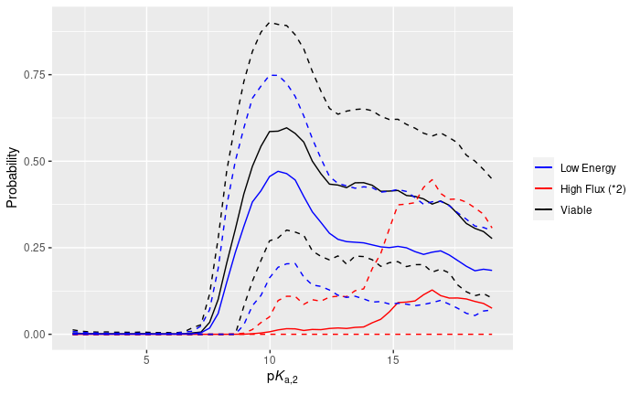

```r
ggplot() +
  # Full region
  geom_path(data = margin.reg1$var, mapping = aes(x = pka2, y = l.pka2, color = 'Full'), linetype = 2) +
  geom_path(data = margin.reg1$var, mapping = aes(x = pka2, y = h.pka2, color = 'Full'), linetype = 2) +
  geom_path(data = margin.reg1$var, mapping = aes(x = pka2, y = p.pka2, color = 'Full')) +
  # High flux region
  geom_path(data = margin.reg2$var, mapping = aes(x = pka2, y = l.pka2*2, color = 'Flux'), linetype = 2) +
  geom_path(data = margin.reg2$var, mapping = aes(x = pka2, y = h.pka2*2, color = 'Flux'), linetype = 2) +
  geom_path(data = margin.reg2$var, mapping = aes(x = pka2, y = p.pka2*2, color = 'Flux')) +
  # Low Energy region
  geom_path(data = margin.reg3$var, mapping = aes(x = pka2, y = l.pka2, color = 'Ener'), linetype = 2) +
  geom_path(data = margin.reg3$var, mapping = aes(x = pka2, y = h.pka2, color = 'Ener'), linetype = 2) +
  geom_path(data = margin.reg3$var, mapping = aes(x = pka2, y = p.pka2, color = 'Ener')) +
  labs(x = expression('p'*italic(K)['a,2']), y = 'Probability', color = '') +
  scale_color_manual(name = '',
                     labels = c('Full' = 'Viable', 'Flux' = 'High Flux (*2)', 'Ener' = 'Low Energy'),
                     values = c('Full' = 'black', 'Flux' = 'red', 'Ener' = 'blue'))
```

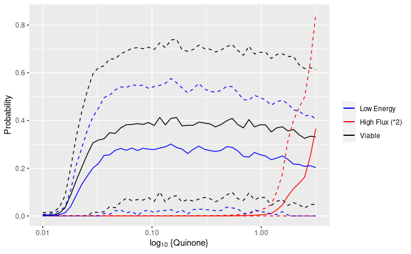

```r
ggplot() +
  # Full region
  geom_path(data = margin.reg1$var, mapping = aes(x = 10^logA, y = l.logA, color = 'Full'), linetype = 2) +
  geom_path(data = margin.reg1$var, mapping = aes(x = 10^logA, y = h.logA, color = 'Full'), linetype = 2) +
  geom_path(data = margin.reg1$var, mapping = aes(x = 10^logA, y = p.logA, color = 'Full')) +
  # High flux region
  geom_path(data = margin.reg2$var, mapping = aes(x = 10^logA, y = l.logA*2, color = 'Flux'), linetype = 2) +
  geom_path(data = margin.reg2$var, mapping = aes(x = 10^logA, y = h.logA*2, color = 'Flux'), linetype = 2) +
  geom_path(data = margin.reg2$var, mapping = aes(x = 10^logA, y = p.logA*2, color = 'Flux')) +
  # Low Energy region
  geom_path(data = margin.reg3$var, mapping = aes(x = 10^logA, y = l.logA, color = 'Ener'), linetype = 2) +
  geom_path(data = margin.reg3$var, mapping = aes(x = 10^logA, y = h.logA, color = 'Ener'), linetype = 2) +
  geom_path(data = margin.reg3$var, mapping = aes(x = 10^logA, y = p.logA, color = 'Ener')) +
  labs(x = expression('log'[10]*' {Quinone}'), y = 'Probability', color = '') +
  scale_color_manual(name = '',
                     labels = c('Full' = 'Viable', 'Flux' = 'High Flux (*2)', 'Ener' = 'Low Energy'),
                     values = c('Full' = 'black', 'Flux' = 'red', 'Ener' = 'blue')) +
  scale_x_log10()
```

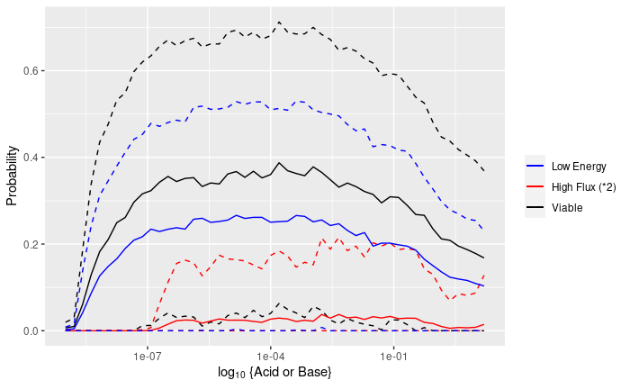

```r
ggplot() +
  # Full region
  geom_path(data = margin.reg1$var, mapping = aes(x = 10^Na.A, y = l.Na.A, color = 'Full'), linetype = 2) +
  geom_path(data = margin.reg1$var, mapping = aes(x = 10^Na.A, y = h.Na.A, color = 'Full'), linetype = 2) +
  geom_path(data = margin.reg1$var, mapping = aes(x = 10^Na.A, y = p.Na.A, color = 'Full')) +
  # High flux region
  geom_path(data = margin.reg2$var, mapping = aes(x = 10^Na.A, y = l.Na.A*2, color = 'Flux'), linetype = 2) +
  geom_path(data = margin.reg2$var, mapping = aes(x = 10^Na.A, y = h.Na.A*2, color = 'Flux'), linetype = 2) +
  geom_path(data = margin.reg2$var, mapping = aes(x = 10^Na.A, y = p.Na.A*2, color = 'Flux')) +
  # Low Energy region
  geom_path(data = margin.reg3$var, mapping = aes(x = 10^Na.A, y = l.Na.A, color = 'Ener'), linetype = 2) +
  geom_path(data = margin.reg3$var, mapping = aes(x = 10^Na.A, y = h.Na.A, color = 'Ener'), linetype = 2) +
  geom_path(data = margin.reg3$var, mapping = aes(x = 10^Na.A, y = p.Na.A, color = 'Ener')) +
  labs(x = expression('log'[10]*' {Acid or Base}'), y = 'Probability', color = '') +
  scale_color_manual(name = '',
                     labels = c('Full' = 'Viable', 'Flux' = 'High Flux (*2)', 'Ener' = 'Low Energy'),
                     values = c('Full' = 'black', 'Flux' = 'red', 'Ener' = 'blue')) +
  scale_x_log10()
```

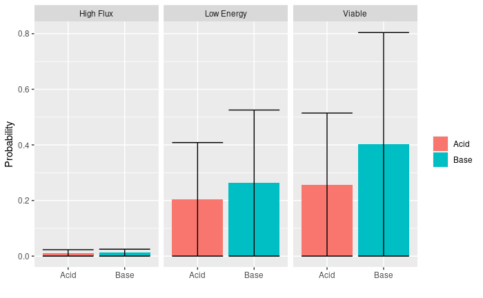

```r
# Acid/base: side-by-side
acid.base = data.frame(typ = c('Acid', 'Base'),
                       p = c(margin.reg1$base$p, margin.reg2$base$p, margin.reg3$base$p),
                       s = c(margin.reg1$base$p, margin.reg2$base$p, margin.reg3$base$p),
                       reg = c('Viable', 'Viable', 'High Flux', 'High Flux', 'Low Energy', 'Low Energy'))
ggplot(acid.base) +
  geom_col(mapping = aes(x = typ, y = p, fill = as.factor(typ))) +
  geom_errorbar(mapping = aes(x = typ, ymin = p+s, ymax = p-s)) +
  facet_wrap(~reg) +
  labs(x = '', y = 'Probability', fill = '')
```

Single variable marginals indicate peaks in the pKas/pH-correction and a threshold for the concentration, regardless of the condition. The marginals for low energy and viable performance (competitive vs MEA) are similar, indicating the importance of energy demands to being competitive.

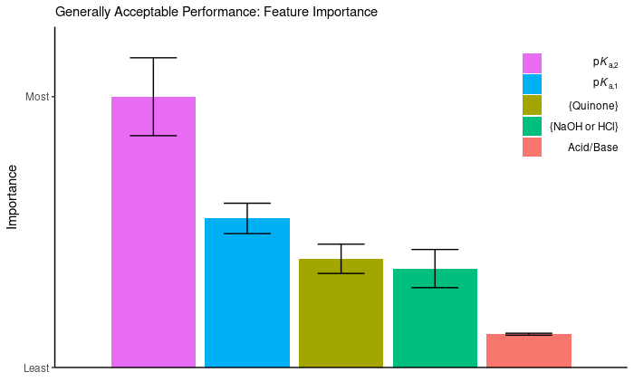

```r
# Plot results
ggplot(import.reg1[order(import.reg1$rank, decreasing = TRUE),]) +
  geom_col(mapping = aes(x = 1:nrow(import.reg1), y = rank/max(rank), fill = var)) +
  geom_errorbar(mapping = aes(x = 1:nrow(import.reg1), y = rank/max(rank),
                              ymin = (rank-uncert)/max(rank), ymax = (rank+uncert)/max(rank)), width = 0.5) +
  labs(x = '', y = '', color = '', subtitle = 'Generally Acceptable Performance: Feature Importance') +
  scale_fill_discrete(labels = c('pka1' = expression('p'*italic(K)['a,1']),
    'pka2' = expression('p'*italic(K)['a,2']), 'logA' = '{Quinone}',
    'Na.A' = '{NaOH or HCl}', 'Base' = 'Acid/Base'),
    breaks = import.reg1$var[order(import.reg1$rank, decreasing = TRUE)], name = '') +
  scale_x_discrete(labels = c()) +
  scale_y_continuous(breaks = c(0, 1), expand = expansion(mult = c(0, .1)),
                     labels = c('Least', 'Most'), name = 'Importance') +
  theme_classic() +
  theme(legend.position = c(0.9, 0.8))
```

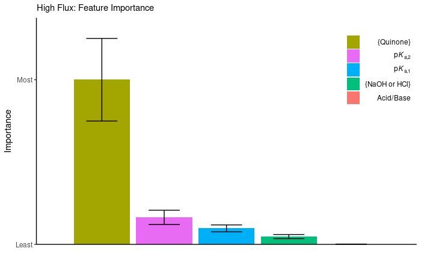

```r
ggplot(import.reg2[order(import.reg2$rank, decreasing = TRUE),]) +
  geom_col(mapping = aes(x = 1:nrow(import.reg2), y = rank/max(rank), fill = var)) +
  geom_errorbar(mapping = aes(x = 1:nrow(import.reg2), y = rank/max(rank),
                              ymin = (rank-uncert)/max(rank), ymax = (rank+uncert)/max(rank)), width = 0.5) +
  labs(x = '', y = '', color = '', subtitle = 'High Flux: Feature Importance') +
  scale_fill_discrete(labels = c('pka1' = expression('p'*italic(K)['a,1']),
    'pka2' = expression('p'*italic(K)['a,2']), 'logA' = '{Quinone}',
    'Na.A' = '{NaOH or HCl}', 'Base' = 'Acid/Base'),
    breaks = import.reg2$var[order(import.reg2$rank, decreasing = TRUE)], name = '') +
  scale_x_discrete(labels = c()) +
  scale_y_continuous(breaks = c(0, 1), expand = expansion(mult = c(0, .1)),
                     labels = c('Least', 'Most'), name = 'Importance') +
  theme_classic() +
  theme(legend.position = c(0.9, 0.8))
```

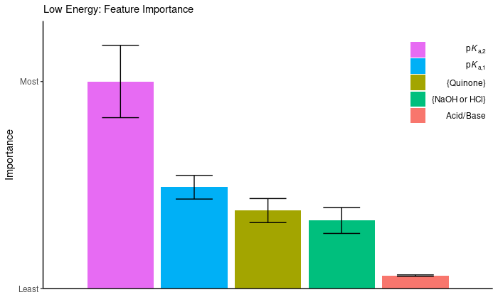

```r
ggplot(import.reg3[order(import.reg3$rank, decreasing = TRUE),]) +
  geom_col(mapping = aes(x = 1:nrow(import.reg3), y = rank/max(rank), fill = var)) +
  geom_errorbar(mapping = aes(x = 1:nrow(import.reg3), y = rank/max(rank),
                              ymin = (rank-uncert)/max(rank), ymax = (rank+uncert)/max(rank)), width = 0.5) +
  labs(x = '', y = '', color = '', subtitle = 'Low Energy: Feature Importance') +
  scale_fill_discrete(labels = c('pka1' = expression('p'*italic(K)['a,1']),
    'pka2' = expression('p'*italic(K)['a,2']), 'logA' = '{Quinone}',
    'Na.A' = '{NaOH or HCl}', 'Base' = 'Acid/Base'),
    breaks = import.reg3$var[order(import.reg3$rank, decreasing = TRUE)], name = '') +
  scale_x_discrete(labels = c()) +
  scale_y_continuous(breaks = c(0, 1), expand = expansion(mult = c(0, .1)),
                     labels = c('Least', 'Most'), name = 'Importance') +
  theme_classic() +
  theme(legend.position = c(0.9, 0.8))
```

```r
NA
NA
```

```r
marginals1D.rel = function(E.cutof, F.cutof, mod.flux.a, mod.ener.a, mod.flux.b, mod.ener.b){
  # Cutoff values should be converted based on the model conversions to log units
  E.cutof = log10(E.cutof)
  # F.cutof = F.cutof
  # Constants
  resolution = 50; MCsamp = 1000
  pka1.rng = c(2, 13.5); pka2.rng = c(0, 5.5)
  logA.rng = c(-2, 0.5); Na.A.rng = c(-7, 0.7)

  # Dataframe storage
  post.optim = data.frame(pka1 = seq(from = pka1.rng[1], to = pka1.rng[2], length.out = resolution),
                          pka2 = seq(from = pka2.rng[1], to = pka2.rng[2],
                                     length.out = resolution),
                          logA = seq(from = logA.rng[1], to = logA.rng[2], length.out = resolution),
                          Na.A = seq(from = Na.A.rng[1], to = Na.A.rng[2],
                                     length.out = resolution),
          # Combined acid and base for importance ranking
          p.pka1 = NaN, p.pka2 = NaN, p.logA = NaN, p.Na.A = NaN, # Probability acceptance median
          s.pka1 = NaN, s.pka2 = NaN, s.logA = NaN, s.Na.A = NaN, # variance for importance ranking
          # Acid and base separated for marginalization plotting
          pa.pka1 = NaN, pa.pka2 = NaN, pa.logA = NaN, pa.Na.A = NaN, # Probability acceptance median
          sa.pka1 = NaN, sa.pka2 = NaN, sa.logA = NaN, sa.Na.A = NaN, # variance for importance ranking
          pb.pka1 = NaN, pb.pka2 = NaN, pb.logA = NaN, pb.Na.A = NaN, # Probability acceptance median
          sb.pka1 = NaN, sb.pka2 = NaN, sb.logA = NaN, sb.Na.A = NaN, # variance for importance ranking
          sd.pka1 = NaN, sd.pka2 = NaN, sd.logA = NaN, sd.Na.A = NaN) # importance ranking uncertainty

  # Monte Carlo loop
  for(i in 1:resolution){
    # pka1
    fill.frame = data.frame(pka1 = post.optim$pka1[i],
                            pka2 = runif(n = MCsamp, min = pka2.rng[1], max = pka2.rng[2]),
                            logA = runif(n = MCsamp, min = logA.rng[1], max = logA.rng[2]),
                            Na.A = runif(n = MCsamp, min = Na.A.rng[1], max = Na.A.rng[2]))
    fill.frame$Na.A = fill.frame$logA + fill.frame$Na.A
    set.flux = sample(1:length(mod.flux.a), length(mod.flux.a))
    set.ener = sample(1:length(mod.flux.a), length(mod.flux.a))
    p.a = c(); s.a = c(); p.b = c(); s.b = c();
    for(j in 1:length(set.flux)){
      # For the purposes of combining systems, only use the same acid/base condition
      res.flux = predict(object = mod.flux.a[[set.flux[j]]], newdata = fill.frame, type = 'UK')
      res.ener = predict(object = mod.ener.a[[set.ener[j]]], newdata = fill.frame, type = 'UK')
      p.accept = (1 - pnorm(q = 0, mean = res.flux$mean - F.cutof, sd = res.flux$sd)) *
        pnorm(q = 0, mean = res.ener$mean - E.cutof, sd = res.ener$sd)
      p.a[j] = mean(p.accept)
      s.a[j] = sd(p.accept)
      # Base
      res.flux = predict(object = mod.flux.b[[set.flux[j]]], newdata = fill.frame, type = 'UK')
      res.ener = predict(object = mod.ener.b[[set.ener[j]]], newdata = fill.frame, type = 'UK')
      p.accept = (1 - pnorm(q = 0, mean = res.flux$mean - F.cutof, sd = res.flux$sd)) *
        pnorm(q = 0, mean = res.ener$mean - E.cutof, sd = res.ener$sd)
      p.b[j] = mean(p.accept)
      s.b[j] = sd(p.accept)
    }
    # Acid/base for marginal
    post.optim$pa.pka1[i] = mean(p.a);  post.optim$pb.pka1[i] = mean(p.b)
    post.optim$sa.pka1[i] = sd(p.a);  post.optim$sb.pka1[i] = sd(p.b)
    post.optim$p.pka1[i] = mean(c(p.a, p.b));
    post.optim$s.pka1[i] = sqrt(mean(c(s.a, s.b)^2)); # Average Variance, not average standard deviation
    post.optim$sd.pka1[i] = sd(c(s.a, s.b)) # Variance of the variance for importance ranking uncertainty

    # pka2
    fill.frame = data.frame(pka2 = post.optim$pka2[i],
                            pka1 = runif(n = MCsamp, min = pka1.rng[1], max = pka1.rng[2]),
                            logA = runif(n = MCsamp, min = logA.rng[1], max = logA.rng[2]),
                            Na.A = runif(n = MCsamp, min = Na.A.rng[1], max = Na.A.rng[2]))
    fill.frame$Na.A = fill.frame$logA + fill.frame$Na.A
    p.a = c(); s.a = c(); p.b = c(); s.b = c();
    for(j in 1:length(set.flux)){
      # For the purposes of combining systems, only use the same acid/base condition
      res.flux = predict(object = mod.flux.a[[set.flux[j]]], newdata = fill.frame, type = 'UK')
      res.ener = predict(object = mod.ener.a[[set.ener[j]]], newdata = fill.frame, type = 'UK')
      p.accept = (1 - pnorm(q = 0, mean = res.flux$mean - F.cutof, sd = res.flux$sd)) *
        pnorm(q = 0, mean = res.ener$mean - E.cutof, sd = res.ener$sd)
      p.a[j] = mean(p.accept)
      s.a[j] = sd(p.accept)
      # Base
      res.flux = predict(object = mod.flux.b[[set.flux[j]]], newdata = fill.frame, type = 'UK')
      res.ener = predict(object = mod.ener.b[[set.ener[j]]], newdata = fill.frame, type = 'UK')
      p.accept = (1 - pnorm(q = 0, mean = res.flux$mean - F.cutof, sd = res.flux$sd)) *
        pnorm(q = 0, mean = res.ener$mean - E.cutof, sd = res.ener$sd)
      p.b[j] = mean(p.accept)
      s.b[j] = sd(p.accept)
    }
    # Acid/base for marginal
    post.optim$pa.pka2[i] = mean(p.a);  post.optim$pb.pka2[i] = mean(p.b)
    post.optim$sa.pka2[i] = sd(p.a);  post.optim$sb.pka2[i] = sd(p.b)
    post.optim$p.pka2[i] = mean(c(p.a, p.b));
    post.optim$s.pka2[i] = sqrt(mean(c(s.a, s.b)^2));
    post.optim$sd.pka2[i] = sd(c(s.a, s.b))

    # log Quinone
    fill.frame = data.frame(logA = post.optim$logA[i],
                            pka1 = runif(n = MCsamp, min = pka1.rng[1], max = pka1.rng[2]),
                            pka2 = runif(n = MCsamp, min = pka2.rng[1], max = pka2.rng[2]),
                            Na.A = runif(n = MCsamp, min = Na.A.rng[1], max = Na.A.rng[2]))
    fill.frame$pka2 = fill.frame$pka1 + fill.frame$pka2
    fill.frame$Na.A = fill.frame$logA + fill.frame$Na.A
    p.a = c(); s.a = c(); p.b = c(); s.b = c();
    for(j in 1:length(set.flux)){
      # For the purposes of combining systems, only use the same acid/base condition
      res.flux = predict(object = mod.flux.a[[set.flux[j]]], newdata = fill.frame, type = 'UK')
      res.ener = predict(object = mod.ener.a[[set.ener[j]]], newdata = fill.frame, type = 'UK')
      p.accept = (1 - pnorm(q = 0, mean = res.flux$mean - F.cutof, sd = res.flux$sd)) *
        pnorm(q = 0, mean = res.ener$mean - E.cutof, sd = res.ener$sd)
      p.a[j] = mean(p.accept)
      s.a[j] = sd(p.accept)
      # Base
      res.flux = predict(object = mod.flux.b[[set.flux[j]]], newdata = fill.frame, type = 'UK')
      res.ener = predict(object = mod.ener.b[[set.ener[j]]], newdata = fill.frame, type = 'UK')
      p.accept = (1 - pnorm(q = 0, mean = res.flux$mean - F.cutof, sd = res.flux$sd)) *
        pnorm(q = 0, mean = res.ener$mean - E.cutof, sd = res.ener$sd)
      p.b[j] = mean(p.accept)
      s.b[j] = sd(p.accept)
    }
    # Acid/base for marginal
    post.optim$pa.logA[i] = mean(p.a);  post.optim$pb.logA[i] = mean(p.b)
    post.optim$sa.logA[i] = sd(p.a);  post.optim$sb.logA[i] = sd(p.b)
    post.optim$p.logA[i] = mean(c(p.a, p.b));
    post.optim$s.logA[i] = sqrt(mean(c(s.a, s.b)^2));
    post.optim$sd.logA[i] = sd(c(s.a, s.b))
```

```r
    # Na/A
    fill.frame = data.frame(Na.A = post.optim$Na.A[i],
                            pka1 = runif(n = MCsamp, min = pka1.rng[1], max = pka1.rng[2]),
                            pka2 = runif(n = MCsamp, min = pka2.rng[1], max = pka2.rng[2]),
                            logA = runif(n = MCsamp, min = logA.rng[1], max = logA.rng[2]))
    fill.frame$pka2 = fill.frame$pka1 + fill.frame$pka2
    p.a = c(); s.a = c(); p.b = c(); s.b = c();
    for(j in 1:length(set.flux)){
      # For the purposes of combining systems, only use the same acid/base condition
      res.flux = predict(object = mod.flux.a[[set.flux[j]]], newdata = fill.frame, type = 'UK')
      res.ener = predict(object = mod.ener.a[[set.ener[j]]], newdata = fill.frame, type = 'UK')
      p.accept = (1 - pnorm(q = 0, mean = res.flux$mean - F.cutof, sd = res.flux$sd)) *
        pnorm(q = 0, mean = res.ener$mean - E.cutof, sd = res.ener$sd)
      p.a[j] = mean(p.accept)
      s.a[j] = sd(p.accept)
      # Base
      res.flux = predict(object = mod.flux.b[[set.flux[j]]], newdata = fill.frame, type = 'UK')
      res.ener = predict(object = mod.ener.b[[set.ener[j]]], newdata = fill.frame, type = 'UK')
      p.accept = (1 - pnorm(q = 0, mean = res.flux$mean - F.cutof, sd = res.flux$sd)) *
        pnorm(q = 0, mean = res.ener$mean - E.cutof, sd = res.ener$sd)
      p.b[j] = mean(p.accept)
      s.b[j] = sd(p.accept)
    }
    # Acid/base for marginal
    post.optim$pa.Na.A[i] = mean(p.a);  post.optim$pb.Na.A[i] = mean(p.b)
    post.optim$sa.Na.A[i] = sd(p.a);  post.optim$sb.Na.A[i] = sd(p.b)
    post.optim$p.Na.A[i] = mean(c(p.a, p.b));
    post.optim$s.Na.A[i] = sqrt(mean(c(s.a, s.b)^2));
    post.optim$sd.Na.A[i] = sd(c(s.a, s.b))
  }

  # Acid/base determination
  typ = c(-1, +1);
  fill.frame = data.frame(pka1 = runif(n = MCsamp, min = pka1.rng[1], max = pka1.rng[2]),
                          pka2 = runif(n = MCsamp, min = pka2.rng[1], max = pka2.rng[2]),
                          logA = runif(n = MCsamp, min = logA.rng[1], max = logA.rng[2]),
                          Na.A = runif(n = MCsamp, min = Na.A.rng[1], max = Na.A.rng[2]))
  fill.frame$Na.A = fill.frame$logA + fill.frame$Na.A
  fill.frame$pka2 = fill.frame$pka1 + fill.frame$pka2
  set.flux = sample(1:length(mod.flux.a), length(mod.flux.a))
  set.ener = sample(1:length(mod.ener.a), length(mod.ener.a))
  p.a = c(); s.a = c(); p.b = c(); s.b = c()
  for(j in 1:length(set.flux)){
    res.flux = predict(object = mod.flux.a[[set.flux[j]]], newdata = fill.frame, type = 'UK')
    res.ener = predict(object = mod.ener.a[[set.ener[j]]], newdata = fill.frame, type = 'UK')
    p.accept = (1 - pnorm(q = 0, mean = res.flux$mean - F.cutof, sd = res.flux$sd)) *
      pnorm(q = 0, mean = res.ener$mean - E.cutof, sd = res.ener$sd)
    p.a[j] = mean(p.accept)
    s.a[j] = sd(p.accept)
    res.flux = predict(object = mod.flux.b[[set.flux[j]]], newdata = fill.frame, type = 'UK')
    res.ener = predict(object = mod.ener.b[[set.ener[j]]], newdata = fill.frame, type = 'UK')
    p.accept = (1 - pnorm(q = 0, mean = res.flux$mean - F.cutof, sd = res.flux$sd)) *
      pnorm(q = 0, mean = res.ener$mean - E.cutof, sd = res.ener$sd)
    p.b[j] = mean(p.accept)
    s.b[j] = sd(p.accept)
  }
  post.opt.typ = data.frame(typ = typ,
                            p = c(mean(p.a), mean(p.b)),
                            s = c(sqrt(mean(s.a^2)), sqrt(mean(s.b^2))),
                            sd = c(sd(s.a), sd(s.b)) )
  # For plotting, probability is bounded [0, 1]
  # pka1
  post.optim$l.pka1 = post.optim$p.pka1 - post.optim$s.pka1
  post.optim$l.pka1[post.optim$l.pka1 < 0] = 0
  post.optim$h.pka1 = post.optim$p.pka1 + post.optim$s.pka1
  post.optim$h.pka1[post.optim$h.pka1 > 1] = 1
  # pka2
  post.optim$l.pka2 = post.optim$p.pka2 - post.optim$s.pka2
  post.optim$l.pka2[post.optim$l.pka2 < 0] = 0
  post.optim$h.pka2 = post.optim$p.pka2 + post.optim$s.pka2
  post.optim$h.pka2[post.optim$h.pka2 > 1] = 1
  # logA
  post.optim$l.logA = post.optim$p.logA - post.optim$s.logA
  post.optim$l.logA[post.optim$l.logA < 0] = 0
  post.optim$h.logA = post.optim$p.logA + post.optim$s.logA
  post.optim$h.logA[post.optim$h.logA > 1] = 1
  # Na.A
  post.optim$l.Na.A = post.optim$p.Na.A - post.optim$s.Na.A
  post.optim$l.Na.A[post.optim$l.Na.A < 0] = 0
  post.optim$h.Na.A = post.optim$p.Na.A + post.optim$s.Na.A
  post.optim$h.Na.A[post.optim$h.Na.A > 1] = 1
  # Acid/Base
  post.opt.typ$l = post.opt.typ$p - post.opt.typ$s
  post.opt.typ$l[post.opt.typ$l < 0] = 0
  post.opt.typ$h = post.opt.typ$p + post.opt.typ$s
  post.opt.typ$h[post.opt.typ$h > 1] = 1

  return(list(var = post.optim, base = post.opt.typ))
}

# Take the marginals
import.rank.rel = function(post.optim, post.opt.typ){
  # Calculating the rankings
  # Higher variance = other variables are more important (inverse of variance = more important control variable)
  # Greater range of probabilities = more important
  import = data.frame(rng = c(diff(range(post.optim$p.pka1)), diff(range(post.optim$p.pka2)),
                              diff(range(post.optim$p.logA)), diff(range(post.optim$p.Na.A))),
                      area = c(sum(post.optim$s.pka1), sum(post.optim$s.pka2),
                               sum(post.optim$s.logA), sum(post.optim$s.Na.A)),
                      var = c('pka1', 'pka2', 'logA', 'Na.A'),
                      sd = c(sum(post.optim$sd.pka1), sum(post.optim$sd.pka2),
                             sum(post.optim$sd.logA), sum(post.optim$sd.Na.A)))
  import$rank = import$rng/import$area
  import$uncert = import$rank*import$sd/import$area

  import.all = data.frame(rng = diff(range(post.opt.typ$p)),
                          area = sum(post.opt.typ$s), var = 'Base',
                          sd = sum(post.opt.typ$sd))
  import.all$rank = import.all$rng/(import.all$area * nrow(post.optim) / nrow(post.opt.typ))
  import.all$uncert = import.all$rank*import.all$sd/import.all$area
  import.all = rbind(import, import.all)
  return(import.all)
}
```

```r
# Run function: 1D marginals
margin.reg1 = marginals1D.rel(E.cutof = reg.full$max.ener, F.cutof = reg.full$min.flux,
            mod.flux.a.rel, mod.ener.a.rel, mod.flux.b.rel, mod.ener.b.rel)
margin.reg2 = marginals1D.rel(E.cutof = reg.flux$max.ener, F.cutof = reg.flux$min.flux,
            mod.flux.a.rel, mod.ener.a, mod.flux.b.rel, mod.ener.b.rel)
margin.reg3 = marginals1D.rel(E.cutof = reg.ener$max.ener, F.cutof = reg.ener$min.flux,
            mod.flux.a.rel, mod.ener.a.rel, mod.flux.b.rel, mod.ener.b.rel)
# Run function: importance rank
import.reg1 = import.rank.rel(post.optim = margin.reg1$var, post.opt.typ = margin.reg1$base)
import.reg2 = import.rank.rel(post.optim = margin.reg2$var, post.opt.typ = margin.reg2$base)
import.reg3 = import.rank.rel(post.optim = margin.reg3$var, post.opt.typ = margin.reg3$base)

# Store information so it does not have to be run again
margin.reg1$var$region = 'Full Viable Region'
margin.reg2$var$region = 'Maximum Flux'
margin.reg3$var$region = 'Minimum Energy'
write.csv(rbind(margin.reg1$var, margin.reg2$var, margin.reg3$var), '1DMarginals_Relative.csv')

margin.reg1$base$region = 'Full Viable Region'
margin.reg2$base$region = 'Maximum Flux'
margin.reg3$base$region = 'Minimum Energy'
write.csv(rbind(margin.reg1$base, margin.reg2$base, margin.reg3$base), 'AcidBaseMarginal_Relative.csv')

import.reg1$region = 'Full Viable Region'
import.reg2$region = 'Maximum Flux'
import.reg3$region = 'Minimum Energy'
write.csv(rbind(import.reg1, import.reg2, import.reg3), 'ImportanceRanking_Relative.csv')
```

```r
marg = read.csv('1DMarginals_Relative.csv')
base = read.csv('AcidBaseMarginal_Relative.csv')
impo = read.csv('ImportanceRanking_Relative.csv')

margin.reg1 = list(var = filter(marg, region == 'Full Viable Region'),
                   base = filter(base, region == 'Full Viable Region'))
margin.reg2 = list(var = filter(marg, region == 'Maximum Flux'),
                   base = filter(base, region == 'Maximum Flux'))
margin.reg3 = list(var = filter(marg, region == 'Minimum Energy'),
                   base = filter(base, region == 'Minimum Energy'))
import.reg1 = filter(impo, region == 'Full Viable Region')
import.reg2 = filter(impo, region == 'Maximum Flux')
import.reg3 = filter(impo, region == 'Minimum Energy')
```

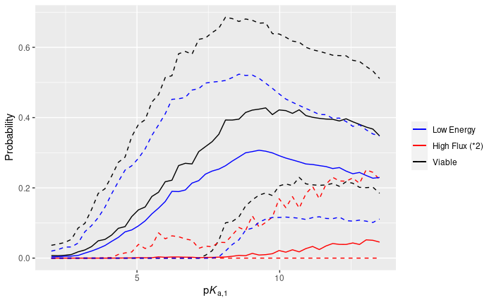

```r
ggplot() +
  # Full region
  geom_path(data = margin.reg1$var, mapping = aes(x = pka1, y = l.pka1, color = 'Full'), linetype = 2) +
  geom_path(data = margin.reg1$var, mapping = aes(x = pka1, y = h.pka1, color = 'Full'), linetype = 2) +
  geom_path(data = margin.reg1$var, mapping = aes(x = pka1, y = p.pka1, color = 'Full')) +
  # High flux region
  geom_path(data = margin.reg2$var, mapping = aes(x = pka1, y = l.pka1*2, color = 'Flux'), linetype = 2) +
  geom_path(data = margin.reg2$var, mapping = aes(x = pka1, y = h.pka1*2, color = 'Flux'), linetype = 2) +
  geom_path(data = margin.reg2$var, mapping = aes(x = pka1, y = p.pka1*2, color = 'Flux')) +
  # Low Energy region
  geom_path(data = margin.reg3$var, mapping = aes(x = pka1, y = l.pka1, color = 'Ener'), linetype = 2) +
  geom_path(data = margin.reg3$var, mapping = aes(x = pka1, y = h.pka1, color = 'Ener'), linetype = 2) +
  geom_path(data = margin.reg3$var, mapping = aes(x = pka1, y = p.pka1, color = 'Ener')) +
  labs(x = expression('p'*italic(K)['a,1']), y = 'Probability', color = '') +
  scale_color_manual(name = '',
                     labels = c('Full' = 'Viable', 'Flux' = 'High Flux (*2)', 'Ener' = 'Low Energy'),
                     values = c('Full' = 'black', 'Flux' = 'red', 'Ener' = 'blue'))
```

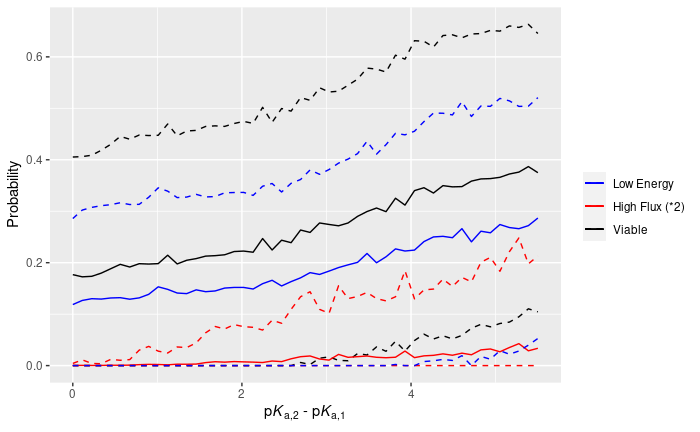

```r
ggplot() +
  # Full region
  geom_path(data = margin.reg1$var, mapping = aes(x = pka2, y = l.pka2, color = 'Full'), linetype = 2) +
  geom_path(data = margin.reg1$var, mapping = aes(x = pka2, y = h.pka2, color = 'Full'), linetype = 2) +
  geom_path(data = margin.reg1$var, mapping = aes(x = pka2, y = p.pka2, color = 'Full')) +
  # High flux region
  geom_path(data = margin.reg2$var, mapping = aes(x = pka2, y = l.pka2*2, color = 'Flux'), linetype = 2) +
  geom_path(data = margin.reg2$var, mapping = aes(x = pka2, y = h.pka2*2, color = 'Flux'), linetype = 2) +
  geom_path(data = margin.reg2$var, mapping = aes(x = pka2, y = p.pka2*2, color = 'Flux')) +
  # Low Energy region
  geom_path(data = margin.reg3$var, mapping = aes(x = pka2, y = l.pka2, color = 'Ener'), linetype = 2) +
  geom_path(data = margin.reg3$var, mapping = aes(x = pka2, y = h.pka2, color = 'Ener'), linetype = 2) +
  geom_path(data = margin.reg3$var, mapping = aes(x = pka2, y = p.pka2, color = 'Ener')) +
  labs(x = expression('p'*italic(K)['a,2']*' - p'*italic(K)['a,1']), y = 'Probability', color = '') +
  scale_color_manual(name = '',
                     labels = c('Full' = 'Viable', 'Flux' = 'High Flux (*2)', 'Ener' = 'Low Energy'),
                     values = c('Full' = 'black', 'Flux' = 'red', 'Ener' = 'blue'))
```

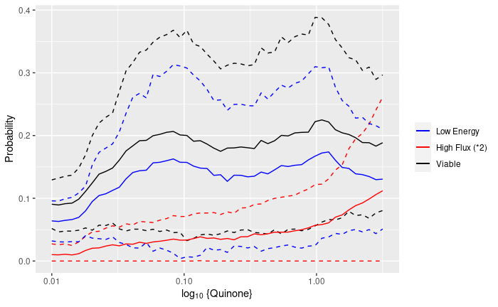

```r
ggplot() +
  # Full region
  geom_path(data = margin.reg1$var, mapping = aes(x = 10^logA, y = l.logA, color = 'Full'), linetype = 2) +
  geom_path(data = margin.reg1$var, mapping = aes(x = 10^logA, y = h.logA, color = 'Full'), linetype = 2) +
  geom_path(data = margin.reg1$var, mapping = aes(x = 10^logA, y = p.logA, color = 'Full')) +
  # High flux region
  geom_path(data = margin.reg2$var, mapping = aes(x = 10^logA, y = l.logA*2, color = 'Flux'), linetype = 2) +
  geom_path(data = margin.reg2$var, mapping = aes(x = 10^logA, y = h.logA*2, color = 'Flux'), linetype = 2) +
  geom_path(data = margin.reg2$var, mapping = aes(x = 10^logA, y = p.logA*2, color = 'Flux')) +
  # Low Energy region
  geom_path(data = margin.reg3$var, mapping = aes(x = 10^logA, y = l.logA, color = 'Ener'), linetype = 2) +
  geom_path(data = margin.reg3$var, mapping = aes(x = 10^logA, y = h.logA, color = 'Ener'), linetype = 2) +
  geom_path(data = margin.reg3$var, mapping = aes(x = 10^logA, y = p.logA, color = 'Ener')) +
  labs(x = expression('log'[10]*' {Quinone}'), y = 'Probability', color = '') +
  scale_color_manual(name = '',
                     labels = c('Full' = 'Viable', 'Flux' = 'High Flux (*2)', 'Ener' = 'Low Energy'),
                     values = c('Full' = 'black', 'Flux' = 'red', 'Ener' = 'blue')) +
  scale_x_log10()
```

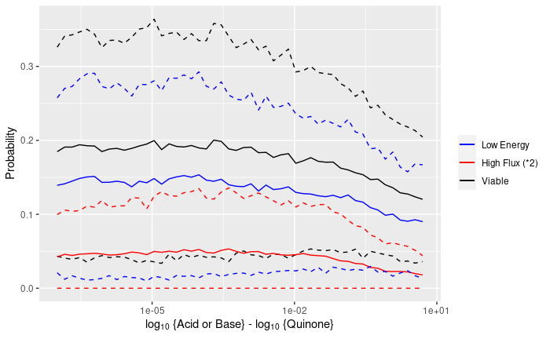

```r
ggplot() +
  # Full region
  geom_path(data = margin.reg1$var, mapping = aes(x = 10^Na.A, y = l.Na.A, color = 'Full'), linetype = 2) +
  geom_path(data = margin.reg1$var, mapping = aes(x = 10^Na.A, y = h.Na.A, color = 'Full'), linetype = 2) +
  geom_path(data = margin.reg1$var, mapping = aes(x = 10^Na.A, y = p.Na.A, color = 'Full')) +
  # High flux region
  geom_path(data = margin.reg2$var, mapping = aes(x = 10^Na.A, y = l.Na.A*2, color = 'Flux'), linetype = 2) +
  geom_path(data = margin.reg2$var, mapping = aes(x = 10^Na.A, y = h.Na.A*2, color = 'Flux'), linetype = 2) +
  geom_path(data = margin.reg2$var, mapping = aes(x = 10^Na.A, y = p.Na.A*2, color = 'Flux')) +
  # Low Energy region
  geom_path(data = margin.reg3$var, mapping = aes(x = 10^Na.A, y = l.Na.A, color = 'Ener'), linetype = 2) +
  geom_path(data = margin.reg3$var, mapping = aes(x = 10^Na.A, y = h.Na.A, color = 'Ener'), linetype = 2) +
  geom_path(data = margin.reg3$var, mapping = aes(x = 10^Na.A, y = p.Na.A, color = 'Ener')) +
  labs(x = expression('log'[10]*' {Acid or Base} - log'[10]*' {Quinone}'), y = 'Probability', color = '') +
  scale_color_manual(name = '',
                     labels = c('Full' = 'Viable', 'Flux' = 'High Flux (*2)', 'Ener' = 'Low Energy'),
                     values = c('Full' = 'black', 'Flux' = 'red', 'Ener' = 'blue')) +
  scale_x_log10()
```

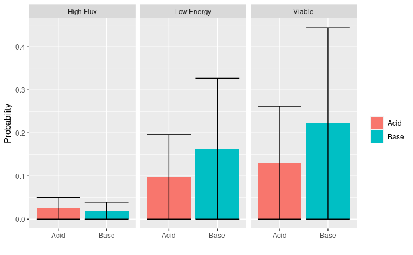

```r
# Acid/base: side-by-side
acid.base = data.frame(typ = c('Acid', 'Base'),
                       p = c(margin.reg1$base$p, margin.reg2$base$p, margin.reg3$base$p),
                       s = c(margin.reg1$base$p, margin.reg2$base$p, margin.reg3$base$p),
                       reg = c('Viable', 'Viable', 'High Flux', 'High Flux', 'Low Energy', 'Low Energy'))
ggplot(acid.base) +
  geom_col(mapping = aes(x = typ, y = p, fill = as.factor(typ))) +
  geom_errorbar(mapping = aes(x = typ, ymin = p+s, ymax = p-s)) +
  facet_wrap(~reg) +
  labs(x = '', y = 'Probability', fill = '')
```

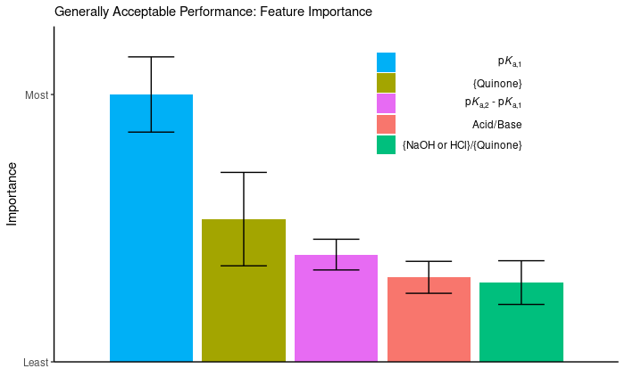

```r
# Plot results
ggplot(import.reg1[order(import.reg1$rank, decreasing = TRUE),]) +
  geom_col(mapping = aes(x = 1:nrow(import.reg1), y = rank/max(rank), fill = var)) +
  geom_errorbar(mapping = aes(x = 1:nrow(import.reg1), y = rank/max(rank),
                              ymin = (rank-uncert)/max(rank), ymax = (rank+uncert)/max(rank)), width = 0.5) +
  labs(x = '', y = '', color = '', subtitle = 'Generally Acceptable Performance: Feature Importance') +
  scale_fill_discrete(labels = c('pka1' = expression('p'*italic(K)['a,1']),
    'pka2' = expression('p'*italic(K)['a,2']*' - p'*italic(K)['a,1']), 'logA' = '{Quinone}',
    'Na.A' = '{NaOH or HCl}/{Quinone}', 'Base' = 'Acid/Base'),
    breaks = import.reg1$var[order(import.reg1$rank, decreasing = TRUE)], name = '') +
  scale_x_discrete(labels = c()) +
  scale_y_continuous(breaks = c(0, 1), expand = expansion(mult = c(0, .1)),
                     labels = c('Least', 'Most'), name = 'Importance') +
  theme_classic() +
  theme(legend.position = c(0.7, 0.8))
```

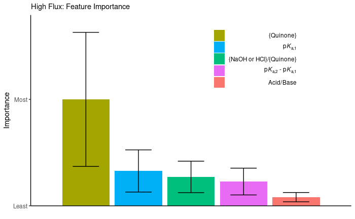

```r
ggplot(import.reg2[order(import.reg2$rank, decreasing = TRUE),]) +
  geom_col(mapping = aes(x = 1:nrow(import.reg2), y = rank/max(rank), fill = var)) +
  geom_errorbar(mapping = aes(x = 1:nrow(import.reg2), y = rank/max(rank),
                              ymin = (rank-uncert)/max(rank), ymax = (rank+uncert)/max(rank)), width = 0.5) +
  labs(x = '', y = '', color = '', subtitle = 'High Flux: Feature Importance') +
  scale_fill_discrete(labels = c('pka1' = expression('p'*italic(K)['a,1']),
    'pka2' = expression('p'*italic(K)['a,2']*' - p'*italic(K)['a,1']), 'logA' = '{Quinone}',
    'Na.A' = '{NaOH or HCl}/{Quinone}', 'Base' = 'Acid/Base'),
    breaks = import.reg2$var[order(import.reg2$rank, decreasing = TRUE)], name = '') +
  scale_x_discrete(labels = c()) +
  scale_y_continuous(breaks = c(0, 1), expand = expansion(mult = c(0, .1)),
                     labels = c('Least', 'Most'), name = 'Importance') +
  theme_classic() +
  theme(legend.position = c(0.7, 0.8))
```

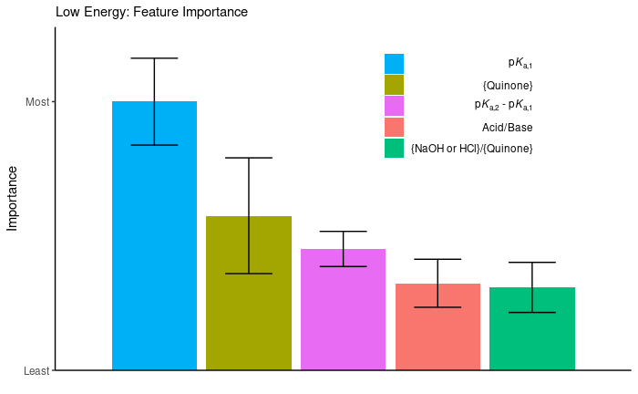

```r
ggplot(import.reg3[order(import.reg3$rank, decreasing = TRUE),]) +
  geom_col(mapping = aes(x = 1:nrow(import.reg3), y = rank/max(rank), fill = var)) +
  geom_errorbar(mapping = aes(x = 1:nrow(import.reg3), y = rank/max(rank),
                              ymin = (rank-uncert)/max(rank), ymax = (rank+uncert)/max(rank)), width = 0.5) +
  labs(x = '', y = '', color = '', subtitle = 'Low Energy: Feature Importance') +
  scale_fill_discrete(labels = c('pka1' = expression('p'*italic(K)['a,1']),
    'pka2' = expression('p'*italic(K)['a,2']*' - p'*italic(K)['a,1']), 'logA' = '{Quinone}',
    'Na.A' = '{NaOH or HCl}/{Quinone}', 'Base' = 'Acid/Base'),
    breaks = import.reg3$var[order(import.reg3$rank, decreasing = TRUE)], name = '') +
  scale_x_discrete(labels = c()) +
  scale_y_continuous(breaks = c(0, 1), expand = expansion(mult = c(0, .1)),
                     labels = c('Least', 'Most'), name = 'Importance') +
  theme_classic() +
  theme(legend.position = c(0.7, 0.8))
```

```r
NA
NA
```

The remainder of this analysis will solely be in terms of natural variables for ease of interpretability.

# Suggested ranges

Since the broad selection criteria and low energy conditions have roughly the same ordering of variables, it is possible to make a function that will output the suggested ranges given the criteria.

Additionally, it makes practical sense to order the variables based on picking the best quinone, then picking the best conditions for that quinone, so even though the high flux condition places the quinone concentration above pKa1 in importance, I will be using the same ordering for this condition.

To ensure that a quinone is likely to exist, a range of pKas and concentrations, rather than a specific point, will be given based on where the peak probability is located. The peak value will still be reported as a test to ensure that the predicted ranges fall within the desired optimal regions.

Preliminary tests of these ranges suggest that, while there is some noise from the Monte Carlo sampling, the optimal regions are continuous, and thus can be described with a lower and upper bound. There will be 2 suggested ranges: a weak and a strong suggestion. The weak suggestion sets the cutoff probability lower than that of the strong suggestion, leading to a wider range for finding a feasible compound. The strong range sets the cutoff at 75% of the peak, while the weak range sets the cutoff at 50% of the peak. Marginals are created assuming less important variables are unknown (can be any value in the range) while the more important variables fit the suggested range. The order is assumed to be pKa2 > pKa1 > {quinone} > {NaOH/HCl} for simplicity. Since quinone concentration and pKa1 are largely independent, switching this ordering for the high flux case is not expected to have a large impact.

```r
suggest.pka2 = function(E.cutof, F.cutof, mod.ener.a, mod.flux.a, mod.ener.b, mod.flux.b, resolution, MCsamp){
  # Constants
  # resolution = 100; MCsamp = 600
  pka1.rng = c(2, 13.5); pka2.rng = c(0, 5.5)
  logA.rng = c(-2, 0.5); Na.A.rng = c(-7, 0.7)

  # Optimal range for pKa2
  range.pka2 = data.frame(pka2 = seq(from = pka1.rng[1] + pka2.rng[1],
                                     to = pka1.rng[2] + pka2.rng[2],
                                     length.out = resolution),
                          p.pka2 = NaN, p.a = NaN, p.b = NaN,
                          s.a = NaN, s.b = NaN)
  # Sample for each point in the range
  for(i in 1:resolution){
    # pka2
    # With pKa2 held constant, pka1 has a truncated range
    pka1.rng.test = c(max(c(pka1.rng[1], range.pka2$pka2[i] - pka2.rng[2])),
                      min(c(pka1.rng[2], range.pka2$pka2[i] - pka2.rng[1])) )
    fill.frame = data.frame(pka2 = range.pka2$pka2[i],
                            pka1 = runif(n = MCsamp, min = pka1.rng.test[1], max = pka1.rng.test[2]),
                            logA = runif(n = MCsamp, min = logA.rng[1], max = logA.rng[2]),
                            Na.A = runif(n = MCsamp, min = Na.A.rng[1], max = Na.A.rng[2]))
    fill.frame$Na.A = fill.frame$Na.A + fill.frame$logA
    set.flux = sample(1:length(mod.flux.a), length(mod.flux.a))
    set.ener = sample(1:length(mod.ener.a), length(mod.ener.a))
    p = c(); p.a = c(); p.b = c()
    for(j in 1:length(set.flux)){
      # Acid
      res.flux = predict(object = mod.flux.a[[set.flux[j]]], newdata = fill.frame, type = 'UK')
      res.ener = predict(object = mod.ener.a[[set.ener[j]]], newdata = fill.frame, type = 'UK')
      p.accept = (1 - pnorm(q = 0, mean = res.flux$mean - F.cutof, sd = res.flux$sd)) *
        pnorm(q = 0, mean = res.ener$mean - E.cutof, sd = res.ener$sd)
      p.a[j] = mean(p.accept)
      # Base
      res.flux = predict(object = mod.flux.b[[set.flux[j]]], newdata = fill.frame, type = 'UK')
      res.ener = predict(object = mod.ener.b[[set.ener[j]]], newdata = fill.frame, type = 'UK')
      p.accept = (1 - pnorm(q = 0, mean = res.flux$mean - F.cutof, sd = res.flux$sd)) *
        pnorm(q = 0, mean = res.ener$mean - E.cutof, sd = res.ener$sd)
      p.b[j] = mean(p.accept)
    }
    range.pka2$p.pka2[i] = mean(c(p.a, p.b))
    range.pka2$p.a[i] = mean(p.a); range.pka2$p.b[i] = mean(p.b)
    range.pka2$s.a[i] = sd(p.a);   range.pka2$s.b[i] = sd(p.b)
  }
  # Suggested ranges
  pka2.wk = filter(range.pka2, p.pka2 > 0.5*diff(range(p.pka2))+min(p.pka2))
  pka2.st = filter(range.pka2, p.pka2 > 0.75*diff(range(p.pka2))+min(p.pka2))
  pka2.rng.wk = range(pka2.wk$pka2)
  pka2.rng.st = range(pka2.st$pka2)
  # Peak values for acid and base
  pka2.pk.wk.a = filter(pka2.wk, p.a == max(p.a))$pka2[1]
  pka2.pk.wk.b = filter(pka2.wk, p.b == max(p.b))$pka2[1]
  pka2.pk.st.a = filter(pka2.st, p.a == max(p.a))$pka2[1]
  pka2.pk.st.b = filter(pka2.st, p.b == max(p.b))$pka2[1]
  # Min values for acid and base
  pka2.lo.wk.a = filter(range.pka2, p.a == min(p.a))$pka2[1]
  pka2.lo.wk.b = filter(range.pka2, p.b == min(p.b))$pka2[1]
  pka2.lo.st.a = filter(range.pka2, p.a == min(p.a))$pka2[1]
  pka2.lo.st.b = filter(range.pka2, p.b == min(p.b))$pka2[1]

  # Also include the median as a possible option for the peak
  return(list(peak = data.frame(wk = pka2.rng.wk, st = pka2.rng.st,
                    pk.wk = c(pka2.pk.wk.a, pka2.pk.wk.b), pk.st = c(pka2.pk.st.a, pka2.pk.st.b),
                    lo.wk = c(pka2.lo.wk.a, pka2.lo.wk.b), lo.st = c(pka2.lo.st.a, pka2.lo.st.b)),
              marginal = data.frame(p = c(range.pka2$p.b, range.pka2$p.a),
                                    s = c(range.pka2$s.a, range.pka2$s.b),
                                    var = range.pka2$pka2, name = 'pka2',
                                    typ = c(rep('+Base', nrow(range.pka2)), rep('+Acid', nrow(range.pka2)))
                                    )))

}

suggest.pka1 = function(E.cutof, F.cutof, mod.ener.a, mod.flux.a, mod.ener.b, mod.flux.b, range.pka2, resolution, MCsamp){
  # Include suggested ranges for more important variables
  pka2.rng.wk = range.pka2$wk; pka2.rng.st = range.pka2$st
  # Set up the marginalization, higher resolution than the single variable marginals for plotting
  # resolution = 100; MCsamp = 600
  pka1.rng = c(2, 13.5); pka2.rng = c(0, 5.5); logA.rng = c(-2, 0.5); Na.A.rng = c(-7, 0.7)

  # Due to the relationship between pKa1 and pKa2, the range of pKa1 is already partially restricted.
  range.pka1.st = data.frame(pka1 = seq(from = max(min(pka1.rng), min(pka2.rng.st) - pka2.rng[2]),
                                        to = min(max(pka1.rng), max(pka2.rng.st) - pka2.rng[1]),
                                        length.out = resolution),
                             p.pka1 = NaN, p.a = NaN, p.b = NaN,
                             s.a = NaN, s.b = NaN)
  range.pka1.wk = data.frame(pka1 = seq(from = max(min(pka1.rng), min(pka2.rng.wk) - pka2.rng[2]),
                                        to = min(max(pka1.rng), max(pka2.rng.wk) - pka2.rng[1]),
                                        length.out = resolution),
                             p.pka1 = NaN, p.a = NaN, p.b = NaN)

  for(i in 1:resolution){
    # Strong suggestion
    pka2.testrng = c(max(min(pka2.rng.st), range.pka1.st$pka1[i] + min(pka2.rng)),
                     min(max(pka2.rng.st), range.pka1.st$pka1[i] + max(pka2.rng)))

    fill.frame = data.frame(pka1 = range.pka1.st$pka1[i],
                            pka2 = runif(n = MCsamp, min = pka2.testrng[1], max = pka2.testrng[2]),
                            logA = runif(n = MCsamp, min = logA.rng[1], max = logA.rng[2]),
                            Na.A = runif(n = MCsamp, min = Na.A.rng[1], max = Na.A.rng[2]))
    fill.frame$Na.A = fill.frame$Na.A + fill.frame$logA
    set.flux = sample(1:length(mod.flux.a), length(mod.flux.a))
    set.ener = sample(1:length(mod.ener.a), length(mod.ener.a))
    p = c(); p.a = c(); p.b = c()
    for(j in 1:length(set.flux)){
      # Acid
      res.flux = predict(object = mod.flux.a[[set.flux[j]]], newdata = fill.frame, type = 'UK')
      res.ener = predict(object = mod.ener.a[[set.ener[j]]], newdata = fill.frame, type = 'UK')
      p.accept = (1 - pnorm(q = 0, mean = res.flux$mean - F.cutof, sd = res.flux$sd)) *
        pnorm(q = 0, mean = res.ener$mean - E.cutof, sd = res.ener$sd)
      p.a[j] = mean(p.accept)
      # Base
      res.flux = predict(object = mod.flux.b[[set.flux[j]]], newdata = fill.frame, type = 'UK')
      res.ener = predict(object = mod.ener.b[[set.ener[j]]], newdata = fill.frame, type = 'UK')
      p.accept = (1 - pnorm(q = 0, mean = res.flux$mean - F.cutof, sd = res.flux$sd)) *
        pnorm(q = 0, mean = res.ener$mean - E.cutof, sd = res.ener$sd)
      p.b[j] = mean(p.accept)
    }
    range.pka1.st$p.pka1[i] = mean(c(p.a, p.b))
    range.pka1.st$p.a[i] = mean(p.a)
    range.pka1.st$p.b[i] = mean(p.b)
    range.pka1.st$s.a[i] = sd(p.a); range.pka1.st$s.b[i] = sd(p.b)
```

```r
    # Weak suggestion
    pka2.testrng = c(max(min(pka2.rng.wk), range.pka1.wk$pka1[i] + min(pka2.rng)),
                     min(max(pka2.rng.wk), range.pka1.wk$pka1[i] + max(pka2.rng)))

    fill.frame = data.frame(pka1 = range.pka1.wk$pka1[i],
                            pka2 = runif(n = MCsamp, min = pka2.testrng[1], max = pka2.testrng[2]),
                            logA = runif(n = MCsamp, min = logA.rng[1], max = logA.rng[2]),
                            Na.A = runif(n = MCsamp, min = Na.A.rng[1], max = Na.A.rng[2]))
    fill.frame$Na.A = fill.frame$Na.A + fill.frame$logA
    set.flux = sample(1:length(mod.flux.a), length(mod.flux.a))
    set.ener = sample(1:length(mod.ener.a), length(mod.ener.a))
    p.accept = c(); p.a = c(); p.b = c()
    for(j in 1:length(set.flux)){
      # Acid
      res.flux = predict(object = mod.flux.a[[set.flux[j]]], newdata = fill.frame, type = 'UK')
      res.ener = predict(object = mod.ener.a[[set.ener[j]]], newdata = fill.frame, type = 'UK')
      p.accept = (1 - pnorm(q = 0, mean = res.flux$mean - F.cutof, sd = res.flux$sd)) *
        pnorm(q = 0, mean = res.ener$mean - E.cutof, sd = res.ener$sd)
      p.a[j] = mean(p.accept)
      # Base
      res.flux = predict(object = mod.flux.b[[set.flux[j]]], newdata = fill.frame, type = 'UK')
      res.ener = predict(object = mod.ener.b[[set.ener[j]]], newdata = fill.frame, type = 'UK')
      p.accept = (1 - pnorm(q = 0, mean = res.flux$mean - F.cutof, sd = res.flux$sd)) *
        pnorm(q = 0, mean = res.ener$mean - E.cutof, sd = res.ener$sd)
      p.b[j] = mean(p.accept)
    }
    range.pka1.wk$p.pka1[i] = mean(c(p.a, p.b))
    range.pka1.wk$p.a[i] = mean(p.a)
    range.pka1.wk$p.b[i] = mean(p.b)
  }
  rm(p, p.a, p.b)
  # Suggestions: find the range so there is less to filter through later
  pka1.wk = filter(range.pka1.wk, p.pka1 > 0.5*diff(range(p.pka1)) +min(p.pka1))
  pka1.st = filter(range.pka1.st, p.pka1 > 0.75*diff(range(p.pka1))+min(p.pka1))
  pka1.rng.wk = range(pka1.wk$pka1)
  pka1.rng.st = range(pka1.st$pka1)
  # Peak values.
  pka1.pk.wk.a = filter(pka1.wk, p.a == max(p.a))$pka1[1]
  pka1.pk.wk.b = filter(pka1.wk, p.b == max(p.b))$pka1[1]
  pka1.pk.st.a = filter(pka1.st, p.a == max(p.a))$pka1[1]
  pka1.pk.st.b = filter(pka1.st, p.b == max(p.b))$pka1[1]
  # Minimum values
  pka1.lo.wk.a = filter(range.pka1.wk, p.a == min(p.a))$pka1[1]
  pka1.lo.wk.b = filter(range.pka1.wk, p.b == min(p.b))$pka1[1]
  pka1.lo.st.a = filter(range.pka1.st, p.a == min(p.a))$pka1[1]
  pka1.lo.st.b = filter(range.pka1.st, p.b == min(p.b))$pka1[1]

  return(list(peak = data.frame(wk = pka1.rng.wk, st = pka1.rng.st,
                    pk.wk = c(pka1.pk.wk.a, pka1.pk.wk.b), pk.st = c(pka1.pk.st.a, pka1.pk.st.b),
                    lo.wk = c(pka1.lo.wk.a, pka1.lo.wk.b), lo.st = c(pka1.lo.st.a, pka1.lo.st.b)),
              marginal = data.frame(p = c(range.pka1.st$p.b, range.pka1.st$p.a),
                                    s = c(range.pka1.st$s.b, range.pka1.st$s.a),
                                    var = range.pka1.st$pka1, name = 'pka1',
                                    typ = c(rep('+Base', nrow(range.pka1.st)), rep('+Acid', nrow(range.pka1.st))))
                                    ))
}

suggest.logA = function(E.cutof, F.cutof, mod.ener.a, mod.flux.a, mod.ener.b, mod.flux.b,
                        range.pka2, range.pka1, resolution, MCsamp){
  # Include suggested ranges for more important variables
  pka2.rng.wk = range.pka2$wk; pka2.rng.st = range.pka2$st
  pka1.rng.wk = range.pka1$wk; pka1.rng.st = range.pka1$st
  # Set up the marginalization, higher resolution than the single variable marginals for plotting
  # resolution = 100; MCsamp = 600
  pka2.rng = c(0, 5.5); logA.rng = c(-2, 0.5); Na.A.rng = c(-7, 0.7)

  range.logA = data.frame(logA = seq(from = min(logA.rng), to = max(logA.rng), length.out = resolution),
                          p.logA.wk = NaN, p.logA.st = NaN,
                          p.a.wk = NaN, p.b.wk = NaN, p.a.st = NaN, p.b.st = NaN,
                          s.a = NaN, s.b = NaN)

  # For random smapling, Constrain pka1 first, then pka2
  for(i in 1:resolution){
    # Strong suggestion
    fill.frame = data.frame(pka1 = runif(n = MCsamp, min = pka1.rng.st[1], max = pka1.rng.st[2]),
                            pka2 = runif(n = MCsamp, min = pka2.rng.st[1], max = pka2.rng.st[2]),
                            logA = range.logA$logA[i],
                            Na.A = runif(n = MCsamp, min = Na.A.rng[1], max = Na.A.rng[2]))
    # Account for the fact that the maximum pKa2 range is higher than the pKa1 range
    fill.frame = filter(fill.frame, pka2 - pka1 < pka2.rng[2], pka2 - pka1 > pka2.rng[1])
    while(nrow(fill.frame) < MCsamp){
      fill.add = data.frame(pka1 = runif(n = MCsamp, min = pka1.rng.st[1], max = pka1.rng.st[2]),
                            pka2 = runif(n = MCsamp, min = pka2.rng.st[1], max = pka2.rng.st[2]),
                            logA = range.logA$logA[i],
                            Na.A = runif(n = MCsamp, min = Na.A.rng[1], max = Na.A.rng[2]))
      fill.add = filter(fill.add, pka2 - pka1 < pka2.rng[2], pka2 - pka1 > pka2.rng[1])
      fill.frame = rbind(fill.frame, fill.add)
    }
    fill.frame = fill.frame[1:MCsamp, ]
    fill.frame$Na.A = fill.frame$Na.A + fill.frame$logA
    set.flux = sample(1:length(mod.flux.a), length(mod.flux.a))
    set.ener = sample(1:length(mod.ener.a), length(mod.ener.a))
    p = c(); p.a = c(); p.b = c()
    for(j in 1:length(set.flux)){
      # Acid
      res.flux = predict(object = mod.flux.a[[set.flux[j]]], newdata = fill.frame, type = 'UK')
      res.ener = predict(object = mod.ener.a[[set.ener[j]]], newdata = fill.frame, type = 'UK')
      p.accept = (1 - pnorm(q = 0, mean = res.flux$mean - F.cutof, sd = res.flux$sd)) *
        pnorm(q = 0, mean = res.ener$mean - E.cutof, sd = res.ener$sd)
      p.a[j] = mean(p.accept)
      # Base
      res.flux = predict(object = mod.flux.b[[set.flux[j]]], newdata = fill.frame, type = 'UK')
      res.ener = predict(object = mod.ener.b[[set.ener[j]]], newdata = fill.frame, type = 'UK')
      p.accept = (1 - pnorm(q = 0, mean = res.flux$mean - F.cutof, sd = res.flux$sd)) *
        pnorm(q = 0, mean = res.ener$mean - E.cutof, sd = res.ener$sd)
      p.b[j] = mean(p.accept)
    }
    range.logA$p.logA.st[i] = mean(c(p.a, p.b))
    range.logA$p.a.st[i] = mean(p.a)
    range.logA$p.b.st[i] = mean(p.b)
    range.logA$s.a[i] = sd(p.a); range.logA$s.b[i] = sd(p.b)
```

```r
    # Weak suggestion
    fill.frame = data.frame(pka1 = runif(n = MCsamp, min = pka1.rng.wk[1], max = pka1.rng.wk[2]),
                            pka2 = runif(n = MCsamp, min = pka2.rng.wk[1], max = pka2.rng.wk[2]),
                            logA = range.logA$logA[i],
                            Na.A = runif(n = MCsamp, min = Na.A.rng[1], max = Na.A.rng[2]))
    # Account for the fact that the maximum pKa2 range is higher than the pKa1 range
    fill.frame = filter(fill.frame, pka2 - pka1 < pka2.rng[2], pka2 - pka1 > pka2.rng[1])
    while(nrow(fill.frame) < MCsamp){
      fill.add = data.frame(pka1 = runif(n = MCsamp, min = pka1.rng.wk[1], max = pka1.rng.wk[2]),
                            pka2 = runif(n = MCsamp, min = pka2.rng.wk[1], max = pka2.rng.wk[2]),
                            logA = range.logA$logA[i],
                            Na.A = runif(n = MCsamp, min = Na.A.rng[1], max = Na.A.rng[2]))
      fill.add = filter(fill.add, pka2 - pka1 < pka2.rng[2], pka2 - pka1 > pka2.rng[1])
      fill.frame = rbind(fill.frame, fill.add)
    }
    fill.frame = fill.frame[1:MCsamp, ]
    fill.frame$Na.A = fill.frame$Na.A + fill.frame$logA
    set.flux = sample(1:length(mod.flux.a), length(mod.flux.a))
    set.ener = sample(1:length(mod.ener.a), length(mod.ener.a))
    p = c(); p.a = c(); p.b = c()
    for(j in 1:length(set.flux)){
      # Acid
      res.flux = predict(object = mod.flux.a[[set.flux[j]]], newdata = fill.frame, type = 'UK')
      res.ener = predict(object = mod.ener.a[[set.ener[j]]], newdata = fill.frame, type = 'UK')
      p.accept = (1 - pnorm(q = 0, mean = res.flux$mean - F.cutof, sd = res.flux$sd)) *
        pnorm(q = 0, mean = res.ener$mean - E.cutof, sd = res.ener$sd)
      p.a[j] = mean(p.accept)
      # Base
      res.flux = predict(object = mod.flux.b[[set.flux[j]]], newdata = fill.frame, type = 'UK')
      res.ener = predict(object = mod.ener.b[[set.ener[j]]], newdata = fill.frame, type = 'UK')
      p.accept = (1 - pnorm(q = 0, mean = res.flux$mean - F.cutof, sd = res.flux$sd)) *
        pnorm(q = 0, mean = res.ener$mean - E.cutof, sd = res.ener$sd)
      p.b[j] = mean(p.accept)
    }
    range.logA$p.logA.wk[i] = mean(c(p.a, p.b))
    range.logA$p.a.wk[i] = mean(p.a)
    range.logA$p.b.wk[i] = mean(p.b)
  }
  # Suggestions
  logA.wk = filter(range.logA, p.logA.wk > 0.5*diff(range(p.logA.wk)) +min(p.logA.wk))
  logA.st = filter(range.logA, p.logA.st > 0.75*diff(range(p.logA.st))+min(p.logA.st))
  logA.rng.wk = range(logA.wk$logA)
  logA.rng.st = range(logA.st$logA)
  # Peaks
  logA.pk.wk.a = filter(logA.wk, p.a.wk == max(p.a.wk))$logA[1]
  logA.pk.wk.b = filter(logA.wk, p.b.wk == max(p.b.wk))$logA[1]
  logA.pk.st.a = filter(logA.st, p.a.st == max(p.a.st))$logA[1]
  logA.pk.st.b = filter(logA.st, p.b.st == max(p.b.st))$logA[1]
  # Peaks
  logA.lo.wk.a = filter(range.logA, p.a.wk == min(p.a.wk))$logA[1]
  logA.lo.wk.b = filter(range.logA, p.b.wk == min(p.b.wk))$logA[1]
  logA.lo.st.a = filter(range.logA, p.a.st == min(p.a.st))$logA[1]
  logA.lo.st.b = filter(range.logA, p.b.st == min(p.b.st))$logA[1]

  return(list(peak = data.frame(wk = logA.rng.wk, st = logA.rng.st,
                    pk.wk = c(logA.pk.wk.a, logA.pk.wk.b), pk.st = c(logA.pk.st.a, logA.pk.st.b),
                    lo.wk = c(logA.lo.wk.a, logA.lo.wk.b), lo.st = c(logA.lo.st.a, logA.lo.st.b)),
              marginal = data.frame(p = c(range.logA$p.b.st, range.logA$p.a.st),
                                    s = c(range.logA$s.b, range.logA$s.a),
                                    var = range.logA$logA, name = 'logA',
                                    typ = c(rep('+Base', nrow(range.logA)), rep('+Acid', nrow(range.logA)))
                                    )))
}

suggest.Na.A = function(E.cutof, F.cutof, mod.ener.a, mod.flux.a, mod.ener.b, mod.flux.b,
                        range.pka2, range.pka1, range.logA, resolution, MCsamp){
  # Include suggested ranges for more important variables
  pka2.rng.wk = range.pka2$wk; pka2.rng.st = range.pka2$st
  pka1.rng.wk = range.pka1$wk; pka1.rng.st = range.pka1$st
  logA.rng.wk = range.logA$wk; logA.rng.st = range.logA$st
  # Set up the marginalization, higher resolution than the single variable marginals for plotting
  # resolution = 100; MCsamp = 600
  pka2.rng = c(0, 5.5); logA.rng = c(-2, 0.5); Na.A.rng = c(-7, 0.7)

  range.Na.A = data.frame(Na.A.wk = seq(from = min(Na.A.rng) + min(logA.rng.wk),
                                        to = max(Na.A.rng) + max(logA.rng.wk), length.out = resolution),
                          Na.A.st = seq(from = min(Na.A.rng) + min(logA.rng.st),
                                        to = max(Na.A.rng) + max(logA.rng.st), length.out = resolution),
                          p.Na.A.wk = NaN, p.Na.A.st = NaN,
                          p.Na.A.a.wk = NaN, p.Na.A.a.st = NaN,
                          p.Na.A.b.wk = NaN, p.Na.A.b.st = NaN,
                          s.a = NaN, s.b = NaN)

  # For random sampling, Constrain pka1 first, then pka2, then logA
  for(i in 1:resolution){
    # Strong suggestion
    logA.rng.test = c(max(logA.rng[1], range.Na.A$Na.A.st[i] - Na.A.rng[2]),
                      min(logA.rng[2], range.Na.A$Na.A.st[i] - Na.A.rng[1]) )
    fill.frame = data.frame(pka1 = runif(n = MCsamp, min = pka1.rng.st[1], max = pka1.rng.st[2]),
                            pka2 = runif(n = MCsamp, min = pka2.rng.st[1], max = pka2.rng.st[2]),
                            logA = runif(n = MCsamp, min = min(logA.rng.test), max = max(logA.rng.test)),
                            Na.A = range.Na.A$Na.A.st[i])
    # Account for the fact that the maximum pKa2 range is higher than the pKa1 range
    fill.frame = filter(fill.frame, pka2 - pka1 < pka2.rng[2], pka2 - pka1 > pka2.rng[1])
    while(nrow(fill.frame) < MCsamp){
      fill.add = data.frame(pka1 = runif(n = MCsamp, min = pka1.rng.st[1], max = pka1.rng.st[2]),
                            pka2 = runif(n = MCsamp, min = pka2.rng.st[1], max = pka2.rng.st[2]),
                            logA = runif(n = MCsamp, min = min(logA.rng.test), max = max(logA.rng.test)),
                            Na.A = range.Na.A$Na.A.st[i])
      fill.add = filter(fill.add, pka2 - pka1 < pka2.rng[2], pka2 - pka1 > pka2.rng[1])
      fill.frame = rbind(fill.frame, fill.add)
    }
    fill.frame = fill.frame[1:MCsamp, ]
    set.flux = sample(1:length(mod.flux.a), length(mod.flux.a))
    set.ener = sample(1:length(mod.ener.a), length(mod.ener.a))
    p = c(); p.a = c(); p.b = c()
    for(j in 1:length(set.flux)){
      # Acid
      res.flux = predict(object = mod.flux.a[[set.flux[j]]], newdata = fill.frame, type = 'UK')
      res.ener = predict(object = mod.ener.a[[set.ener[j]]], newdata = fill.frame, type = 'UK')
      p.accept = (1 - pnorm(q = 0, mean = res.flux$mean - F.cutof, sd = res.flux$sd)) *
        pnorm(q = 0, mean = res.ener$mean - E.cutof, sd = res.ener$sd)
      p.a[j] = mean(p.accept)
      # Base
      res.flux = predict(object = mod.flux.b[[set.flux[j]]], newdata = fill.frame, type = 'UK')
      res.ener = predict(object = mod.ener.b[[set.ener[j]]], newdata = fill.frame, type = 'UK')
      p.accept = (1 - pnorm(q = 0, mean = res.flux$mean - F.cutof, sd = res.flux$sd)) *
        pnorm(q = 0, mean = res.ener$mean - E.cutof, sd = res.ener$sd)
      p.b[j] = mean(p.accept)
    }
    range.Na.A$p.Na.A.st[i] = mean(c(p.a, p.b))
    range.Na.A$p.Na.A.a.st[i] = mean(p.a)
    range.Na.A$p.Na.A.b.st[i] = mean(p.b)
    range.Na.A$s.a[i] = sd(p.a);    range.Na.A$s.b[i] = sd(p.b)
    # Weak suggestion
    logA.rng.test = c(max(logA.rng[1], range.Na.A$Na.A.wk[i] - Na.A.rng[2]),
                      min(logA.rng[2], range.Na.A$Na.A.wk[i] - Na.A.rng[1]) )
    fill.frame = data.frame(pka1 = runif(n = MCsamp, min = pka1.rng.wk[1], max = pka1.rng.wk[2]),
                            pka2 = runif(n = MCsamp, min = pka2.rng.wk[1], max = pka2.rng.wk[2]),
                            logA = runif(n = MCsamp, min = min(logA.rng.test), max = max(logA.rng.test)),
                            Na.A = range.Na.A$Na.A.wk[i])
    # Account for the fact that the maximum pKa2 range is higher than the pKa1 range
    fill.frame = filter(fill.frame, pka2 - pka1 < pka2.rng[2], pka2 - pka1 > pka2.rng[1])
    while(nrow(fill.frame) < MCsamp){
      fill.add = data.frame(pka1 = runif(n = MCsamp, min = pka1.rng.wk[1], max = pka1.rng.wk[2]),
                            pka2 = runif(n = MCsamp, min = pka2.rng.wk[1], max = pka2.rng.wk[2]),
                            logA = runif(n = MCsamp, min = min(logA.rng.test), max = max(logA.rng.test)),
                            Na.A = range.Na.A$Na.A.wk[i])
      fill.add = filter(fill.add, pka2 - pka1 < pka2.rng[2], pka2 - pka1 > pka2.rng[1])
      fill.frame = rbind(fill.frame, fill.add)
    }
    fill.frame = fill.frame[1:MCsamp, ]
    set.flux = sample(1:length(mod.flux.a), length(mod.flux.a))
    set.ener = sample(1:length(mod.ener.a), length(mod.ener.a))
    p = c(); p.a = c(); p.b = c()
    for(j in 1:length(set.flux)){
      # Acid
      res.flux = predict(object = mod.flux.a[[set.flux[j]]], newdata = fill.frame, type = 'UK')
      res.ener = predict(object = mod.ener.a[[set.ener[j]]], newdata = fill.frame, type = 'UK')
      p.accept = (1 - pnorm(q = 0, mean = res.flux$mean - F.cutof, sd = res.flux$sd)) *
        pnorm(q = 0, mean = res.ener$mean - E.cutof, sd = res.ener$sd)
      p.a[j] = mean(p.accept)
      # Base
      res.flux = predict(object = mod.flux.b[[set.flux[j]]], newdata = fill.frame, type = 'UK')
      res.ener = predict(object = mod.ener.b[[set.ener[j]]], newdata = fill.frame, type = 'UK')
      p.accept = (1 - pnorm(q = 0, mean = res.flux$mean - F.cutof, sd = res.flux$sd)) *
        pnorm(q = 0, mean = res.ener$mean - E.cutof, sd = res.ener$sd)
      p.b[j] = mean(p.accept)
    }
    range.Na.A$p.Na.A.wk[i] = mean(c(p.a, p.b))
    range.Na.A$p.Na.A.a.wk[i] = mean(p.a)
    range.Na.A$p.Na.A.b.wk[i] = mean(p.b)
  }
  # Suggested ranges
  Na.A.wk = filter(range.Na.A, p.Na.A.wk > 0.5*diff(range(p.Na.A.wk)) +min(p.Na.A.wk))
  Na.A.st = filter(range.Na.A, p.Na.A.st > 0.75*diff(range(p.Na.A.st))+min(p.Na.A.st))
  Na.A.rng.wk = range(Na.A.wk$Na.A.wk)
  Na.A.rng.st = range(Na.A.st$Na.A.st)
  # Peak values
  Na.A.pk.wk.a = filter(Na.A.wk, p.Na.A.a.wk == max(p.Na.A.a.wk))$Na.A.wk[1]
  Na.A.pk.wk.b = filter(Na.A.wk, p.Na.A.b.wk == max(p.Na.A.b.wk))$Na.A.wk[1]
  Na.A.pk.st.a = filter(Na.A.st, p.Na.A.a.st == max(p.Na.A.a.st))$Na.A.st[1]
  Na.A.pk.st.b = filter(Na.A.st, p.Na.A.b.st == max(p.Na.A.b.st))$Na.A.st[1]
  # Minima values
  Na.A.lo.wk.a = filter(range.Na.A, p.Na.A.a.wk == min(p.Na.A.a.wk))$Na.A.wk[1]
  Na.A.lo.wk.b = filter(range.Na.A, p.Na.A.b.wk == min(p.Na.A.b.wk))$Na.A.wk[1]
  Na.A.lo.st.a = filter(range.Na.A, p.Na.A.a.st == min(p.Na.A.a.st))$Na.A.st[1]
  Na.A.lo.st.b = filter(range.Na.A, p.Na.A.b.st == min(p.Na.A.b.st))$Na.A.st[1]
```

```r
  return(list(peak = data.frame(wk = Na.A.rng.wk, st = Na.A.rng.st,
                    pk.wk = c(Na.A.pk.wk.a, Na.A.pk.wk.b), pk.st = c(Na.A.pk.st.a, Na.A.pk.st.b),
                    lo.wk = c(median(Na.A.lo.wk.a), median(Na.A.lo.wk.b)),
                    lo.st = c(median(Na.A.lo.st.a), median(Na.A.lo.st.b))),
              marginal = data.frame(p = c(range.Na.A$p.Na.A.b.st, range.Na.A$p.Na.A.a.st),
                                    s = c(range.Na.A$s.b, range.Na.A$s.a),
                                    var = range.Na.A$Na.A.st, name = 'logNa.A',
                                    typ = c(rep('+Base', nrow(range.Na.A)), rep('+Acid', nrow(range.Na.A)))
                                    )))
}


suggest.ranges = function(E.cut, F.cut, mod.ener.a, mod.flux.a, mod.ener.b, mod.flux.b){
  # Monte Carlo sample resolution
  resolution = 75; MCsamp = 500
  # Convert energy cutoffs to log units
  E.cut = log10(E.cut)

  region.pka2 = suggest.pka2(E.cutof = E.cut, F.cutof = F.cut,
               mod.ener.a = mod.ener.a, mod.flux.a = mod.flux.a,
               mod.ener.b = mod.ener.b, mod.flux.b = mod.flux.b,
               resolution = resolution, MCsamp = MCsamp)
  region.pka1 = suggest.pka1(E.cutof = E.cut, F.cutof = F.cut,
               mod.ener.a = mod.ener.a, mod.flux.a = mod.flux.a,
               mod.ener.b = mod.ener.b, mod.flux.b = mod.flux.b,
               range.pka2 = region.pka2$peak,
               resolution = resolution, MCsamp = MCsamp)
  region.logA = suggest.logA(E.cutof = E.cut, F.cutof = F.cut,
               mod.ener.a = mod.ener.a, mod.flux.a = mod.flux.a,
               mod.ener.b = mod.ener.b, mod.flux.b = mod.flux.b,
               range.pka2 = region.pka2$peak, range.pka1 = region.pka1$peak,
               resolution = resolution, MCsamp = MCsamp)
  region.Na.A = suggest.Na.A(E.cutof = E.cut, F.cutof = F.cut,
               mod.ener.a = mod.ener.a, mod.flux.a = mod.flux.a,
               mod.ener.b = mod.ener.b, mod.flux.b = mod.flux.b,
               range.pka2 = region.pka2$peak, range.pka1 = region.pka1$peak, range.logA = region.logA$peak,
               resolution = resolution, MCsamp = MCsamp)
  return(list(pka2 = region.pka2$peak, pka1 = region.pka1$peak,
              logA = region.logA$peak, Na.A = region.Na.A$peak,
              marg = rbind(region.pka2$marginal, region.pka1$marginal,
                           region.logA$marginal, region.Na.A$marginal)))
}
```

```r
reg.full.ranges = suggest.ranges(E.cut = reg.full$max.ener, F.cut = reg.full$min.flux,
                                mod.ener.a = mod.ener.a, mod.flux.a = mod.flux.a,
                                mod.ener.b = mod.ener.b, mod.flux.b = mod.flux.b)
reg.flux.ranges = suggest.ranges(E.cut = reg.flux$max.ener, F.cut = reg.flux$min.flux,
                                mod.ener.a = mod.ener.a, mod.flux.a = mod.flux.a,
                                mod.ener.b = mod.ener.b, mod.flux.b = mod.flux.b)
reg.ener.ranges = suggest.ranges(E.cut = reg.ener$max.ener, F.cut = reg.ener$min.flux,
                                mod.ener.a = mod.ener.a, mod.flux.a = mod.flux.a,
                                mod.ener.b = mod.ener.b, mod.flux.b = mod.flux.b)


# Save ranges and marginals
write.csv(x = reg.full.ranges[!names(reg.full.ranges) %in% 'marg'], file = 'AcceptRanges.csv')
write.csv(x = reg.flux.ranges[!names(reg.flux.ranges) %in% 'marg'], file = 'MaxFlxRanges.csv')
write.csv(x = reg.ener.ranges[!names(reg.ener.ranges) %in% 'marg'], file = 'MinEngRanges.csv')

# Save marginals
write.csv(x = reg.full.ranges[names(reg.full.ranges) %in% 'marg'], file = 'AcceptCondMargin.csv')
write.csv(x = reg.flux.ranges[names(reg.flux.ranges) %in% 'marg'], file = 'MaxFlxCondMargin.csv')
write.csv(x = reg.ener.ranges[names(reg.ener.ranges) %in% 'marg'], file = 'MinEngCondMargin.csv')
```

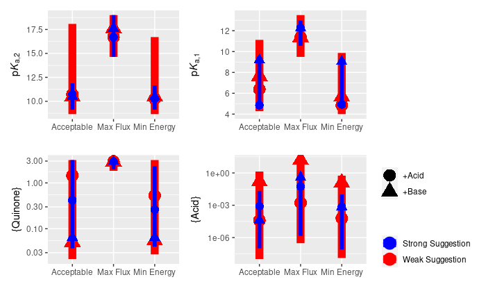

```r
# Load ranges from csv
reg.full.ranges = read.csv(file = 'AcceptRanges.csv')
reg.flux.ranges = read.csv(file = 'MaxFlxRanges.csv')
reg.ener.ranges = read.csv(file = 'MinEngRanges.csv')

sz = 4
g1 = ggplot(data.frame(wk = c(reg.full.ranges$pka2.wk,    reg.flux.ranges$pka2.wk,    reg.ener.ranges$pka2.wk),
                       st = c(reg.full.ranges$pka2.st,    reg.flux.ranges$pka2.st,    reg.ener.ranges$pka2.st),
                    pk.wk = c(reg.full.ranges$pka2.pk.wk, reg.flux.ranges$pka2.pk.wk, reg.ener.ranges$pka2.pk.wk),
                    pk.st = c(reg.full.ranges$pka2.pk.st, reg.flux.ranges$pka2.pk.st, reg.ener.ranges$pka2.pk.st),
                   pk.typ = c('+Acid', '+Base'),
                   labels = c(rep('Acceptable', 2), rep('Max Flux', 2), rep('Min Energy', 2))) ) +
  # Weak
  geom_line(mapping = aes(x = labels, y = wk, color = 'wk'), size = sz) +
  geom_point(mapping = aes(x = labels, y = pk.wk, color = 'wk', shape = pk.typ), size = sz+2) +
  # Strong
  geom_line(mapping = aes(x = labels, y = st, color = 'st'), size = sz/2) +
  geom_point(mapping = aes(x = labels, y = pk.st, color = 'st', shape = pk.typ), size = sz) +
  labs(x = '', y = expression('p'*italic(K)['a,2']), shape = '') +
  scale_color_manual(values = c('wk' = 'red', 'st' = 'blue'),
                     labels = c('wk' = 'Weak Suggestion', 'st' = 'Strong Suggestion'),
                     name = '')
g2 = ggplot(data.frame(wk = c(reg.full.ranges$pka1.wk,    reg.flux.ranges$pka1.wk,    reg.ener.ranges$pka1.wk),
                       st = c(reg.full.ranges$pka1.st,    reg.flux.ranges$pka1.st,    reg.ener.ranges$pka1.st),
                    pk.wk = c(reg.full.ranges$pka1.pk.wk, reg.flux.ranges$pka1.pk.wk, reg.ener.ranges$pka1.pk.wk),
                    pk.st = c(reg.full.ranges$pka1.pk.st, reg.flux.ranges$pka1.pk.st, reg.ener.ranges$pka1.pk.st),
                   pk.typ = c('+Acid', '+Base'),
                   labels = c(rep('Acceptable', 2), rep('Max Flux', 2), rep('Min Energy', 2))) ) +
  # Weak
  geom_line(mapping = aes(x = labels, y = wk, color = 'wk'), size = sz) +
  geom_point(mapping = aes(x = labels, y = pk.wk, color = 'wk', shape = pk.typ), size = sz+2) +
  # Strong
  geom_line(mapping = aes(x = labels, y = st, color = 'st'), size = sz/2) +
  geom_point(mapping = aes(x = labels, y = pk.st, color = 'st', shape = pk.typ), size = sz) +
  labs(x = '', y = expression('p'*italic(K)['a,1']), shape = '') +
  scale_color_manual(values = c('wk' = 'red', 'st' = 'blue'),
                     labels = c('wk' = 'Weak Suggestion', 'st' = 'Strong Suggestion'),
                     name = '')
# g1 + guides(color = FALSE) + g2

g3 = ggplot(data.frame(wk = c(reg.full.ranges$logA.wk,    reg.flux.ranges$logA.wk,    reg.ener.ranges$logA.wk),
                       st = c(reg.full.ranges$logA.st,    reg.flux.ranges$logA.st,    reg.ener.ranges$logA.st),
                    pk.wk = c(reg.full.ranges$logA.pk.wk, reg.flux.ranges$logA.pk.wk, reg.ener.ranges$logA.pk.wk),
                    pk.st = c(reg.full.ranges$logA.pk.st, reg.flux.ranges$logA.pk.st, reg.ener.ranges$logA.pk.st),
                   pk.typ = c('+Acid', '+Base'),
                   labels = c(rep('Acceptable', 2), rep('Max Flux', 2), rep('Min Energy', 2))) ) +
  # Weak
  geom_line(mapping = aes(x = labels, y = 10^wk, color = 'wk'), size = sz) +
  geom_point(mapping = aes(x = labels, y = 10^pk.wk, color = 'wk', shape = pk.typ), size = sz+2) +
  # Strong
  geom_line(mapping = aes(x = labels, y = 10^st, color = 'st'), size = sz/2) +
  geom_point(mapping = aes(x = labels, y = 10^pk.st, color = 'st', shape = pk.typ), size = sz) +
  labs(x = '', y = '{Quinone}', shape = '') + scale_y_log10() +
  scale_color_manual(values = c('wk' = 'red', 'st' = 'blue'),
                     labels = c('wk' = 'Weak Suggestion', 'st' = 'Strong Suggestion'),
                     name = '')
g4 = ggplot(data.frame(wk = c(reg.full.ranges$Na.A.wk,    reg.flux.ranges$Na.A.wk,    reg.ener.ranges$Na.A.wk),
                       st = c(reg.full.ranges$Na.A.st,    reg.flux.ranges$Na.A.st,    reg.ener.ranges$Na.A.st),
                    pk.wk = c(reg.full.ranges$Na.A.pk.wk, reg.flux.ranges$Na.A.pk.wk, reg.ener.ranges$Na.A.pk.wk),
                    pk.st = c(reg.full.ranges$Na.A.pk.st, reg.flux.ranges$Na.A.pk.st, reg.ener.ranges$Na.A.pk.st),
                   pk.typ = c('+Acid', '+Base'),
                   labels = c(rep('Acceptable', 2), rep('Max Flux', 2), rep('Min Energy', 2))) ) +
  # Weak
  geom_line(mapping = aes(x = labels, y = 10^wk, color = 'wk'), size = sz) +
  geom_point(mapping = aes(x = labels, y = 10^pk.wk, color = 'wk', shape = pk.typ), size = sz+2) +
  # Strong
  geom_line(mapping = aes(x = labels, y = 10^st, color = 'st'), size = sz/2) +
  geom_point(mapping = aes(x = labels, y = 10^pk.st, color = 'st', shape = pk.typ), size = sz) +
  labs(x = '', y = '{Acid}', shape = '') + scale_y_log10() +
  scale_color_manual(values = c('wk' = 'red', 'st' = 'blue'),
                     labels = c('wk' = 'Weak Suggestion', 'st' = 'Strong Suggestion'),
                     name = '')
# g3 + guides(color = FALSE) + g4

g1 + guides(color = FALSE, shape = FALSE) +
  g2 + guides(color = FALSE, shape = FALSE) +
  g3 + guides(color = FALSE, shape = FALSE) + g4
```

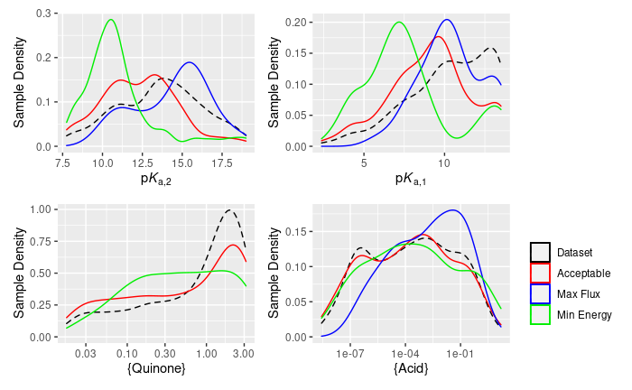

```r
# Compare to the densities
# GPar.nat
g1 = ggplot() +
  geom_density(filter(GPar.nat, Energy.kJ.mol < 100, Flux.mol.m2s > 0),
               mapping = aes(x = pka2, color = '0'), linetype = 2) +
  geom_density(filter(GPar.nat, Energy.kJ.mol < reg.full$max.ener, Flux.mol.m2s > reg.full$min.flux),
               mapping = aes(x = pka2, color = '1')) +
  geom_density(filter(GPar.nat, Energy.kJ.mol < reg.flux$max.ener, Flux.mol.m2s > reg.flux$min.flux),
               mapping = aes(x = pka2, color = '2')) +
  geom_density(filter(GPar.nat, Energy.kJ.mol < reg.ener$max.ener, Flux.mol.m2s > reg.ener$min.flux),
               mapping = aes(x = pka2, color = '3')) +
  scale_color_manual(values = c('0' = 'black', '1' = 'red', '2' = 'blue', '3' = 'green2'),
                     labels = c('0' = 'Dataset', '1' = 'Acceptable', '2' = 'Max Flux', '3' = 'Min Energy')) +
  labs(x = expression('p'*italic(K)['a,2']), y = 'Sample Density')
g2 = ggplot() +
  geom_density(filter(GPar.nat, Energy.kJ.mol < 100, Flux.mol.m2s > 0),
               mapping = aes(x = pka1, color = '0'), linetype = 2) +
  geom_density(filter(GPar.nat, Energy.kJ.mol < reg.full$max.ener, Flux.mol.m2s > reg.full$min.flux),
               mapping = aes(x = pka1, color = '1')) +
  geom_density(filter(GPar.nat, Energy.kJ.mol < reg.flux$max.ener, Flux.mol.m2s > reg.flux$min.flux),
               mapping = aes(x = pka1, color = '2')) +
  geom_density(filter(GPar.nat, Energy.kJ.mol < reg.ener$max.ener, Flux.mol.m2s > reg.ener$min.flux),
               mapping = aes(x = pka1, color = '3')) +
  scale_color_manual(values = c('0' = 'black', '1' = 'red', '2' = 'blue', '3' = 'green2'),
                     labels = c('0' = 'Dataset', '1' = 'Acceptable', '2' = 'Max Flux', '3' = 'Min Energy')) +
  labs(x = expression('p'*italic(K)['a,1']), y = 'Sample Density')
g3 = ggplot() +
  geom_density(filter(GPar.nat, Energy.kJ.mol < 100, Flux.mol.m2s > 0),
               mapping = aes(x = 10^logA, color = '0'), linetype = 2) +
  geom_density(filter(GPar.nat, Energy.kJ.mol < reg.full$max.ener, Flux.mol.m2s > reg.full$min.flux),
               mapping = aes(x = 10^logA, color = '1')) +
  # Omitting the max flux condition because it is skewed entirely to high concentrations
  # and obscures the other of the results
  # geom_density(filter(GPar.nat, Energy.kJ.mol < reg.flux$max.ener, Flux.mol.m2s > reg.flux$min.flux),
  #              mapping = aes(x = 10^logA, color = '2')) +
  geom_density(filter(GPar.nat, Energy.kJ.mol < reg.ener$max.ener, Flux.mol.m2s > reg.ener$min.flux),
               mapping = aes(x = 10^logA, color = '3')) +
  scale_color_manual(values = c('0' = 'black', '1' = 'red', '2' = 'blue', '3' = 'green2'),
                     labels = c('0' = 'Dataset', '1' = 'Acceptable', '2' = 'Max Flux', '3' = 'Min Energy')) +
  scale_x_log10() + labs(x = '{Quinone}', y = 'Sample Density')

g4 = ggplot() +
  geom_density(filter(GPar.nat, Energy.kJ.mol < 100, Flux.mol.m2s > 0),
               mapping = aes(x = 10^Na.A, color = '0'), linetype = 2) +
  geom_density(filter(GPar.nat, Energy.kJ.mol < reg.full$max.ener, Flux.mol.m2s > reg.full$min.flux),
               mapping = aes(x = 10^Na.A, color = '1')) +
  geom_density(filter(GPar.nat, Energy.kJ.mol < reg.flux$max.ener, Flux.mol.m2s > reg.flux$min.flux),
               mapping = aes(x = 10^Na.A, color = '2')) +
  geom_density(filter(GPar.nat, Energy.kJ.mol < reg.ener$max.ener, Flux.mol.m2s > reg.ener$min.flux),
               mapping = aes(x = 10^Na.A, color = '3')) +
  scale_color_manual(values = c('0' = 'black', '1' = 'red', '2' = 'blue', '3' = 'green2'),
                     labels = c('0' = 'Dataset', '1' = 'Acceptable', '2' = 'Max Flux', '3' = 'Min Energy'),
                     name = '') +
  scale_x_log10() +  labs(x = '{Acid}', y = 'Sample Density')
g1 + guides(color = FALSE) + g2 + guides(color = FALSE) + g3 + guides(color = FALSE) + g4
```

```r
rm(g1, g2, g3, g4)
```

The suggested ranges appear to agree with the distribution of sampled points. Generally, high flux conditions require more specific characteristics, in agreement with the fact that this region is very small compared to the other two.

Confirming that the peak points suggested by the marginals fall within the specified regions

```r
reg.full.ranges = read.csv(file = 'AcceptRanges.csv')
reg.flux.ranges = read.csv(file = 'MaxFlxRanges.csv')
reg.ener.ranges = read.csv(file = 'MinEngRanges.csv')

reg.full.pk = data.frame(pka1 = c(reg.full.ranges$pka1.pk.wk, reg.full.ranges$pka1.pk.st),
                        pka2 = c(reg.full.ranges$pka2.pk.wk, reg.full.ranges$pka2.pk.st),
                        logA = c(reg.full.ranges$logA.pk.wk, reg.full.ranges$logA.pk.st),
                        Na.A = c(reg.full.ranges$Na.A.pk.wk, reg.full.ranges$Na.A.pk.st),
                         typ = c(-1, 1), reg = '1')
reg.flux.pk = data.frame(pka1 = c(reg.flux.ranges$pka1.pk.wk, reg.flux.ranges$pka1.pk.st),
                        pka2 = c(reg.flux.ranges$pka2.pk.wk, reg.flux.ranges$pka2.pk.st),
                        logA = c(reg.flux.ranges$logA.pk.wk, reg.flux.ranges$logA.pk.st),
                        Na.A = c(reg.flux.ranges$Na.A.pk.wk, reg.flux.ranges$Na.A.pk.st),
                         typ = c(-1, 1), reg = '2')
reg.ener.pk = data.frame(pka1 = c(reg.ener.ranges$pka1.pk.wk, reg.ener.ranges$pka1.pk.st),
                        pka2 = c(reg.ener.ranges$pka2.pk.wk, reg.ener.ranges$pka2.pk.st),
                        logA = c(reg.ener.ranges$logA.pk.wk, reg.ener.ranges$logA.pk.st),
                        Na.A = c(reg.ener.ranges$Na.A.pk.wk, reg.ener.ranges$Na.A.pk.st),
                         typ = c(-1, 1), reg = '3')
region.pk = rbind(reg.full.pk, reg.flux.pk, reg.ener.pk)
# Some points have pka differences exceeding 5.5. Set them to the minimum pka1 given the more important pka2
region.pk$pka1[abs(region.pk$pka1 - region.pk$pka2) > 5.5] =
  region.pk$pka2[abs(region.pk$pka1 - region.pk$pka2) > 5.5] - 5.5
res = PCET.obj.flu(inputs = as.matrix(region.pk[,c(1:5)]))
region.pk$Energy.kJ.mol = res[1:nrow(region.pk)]
region.pk$Flux.mol.m2s  = res[(nrow(region.pk)+1):length(res)]
rm(res)

# Store for later
region.pk$region = c(rep('Viable', 4), rep('High Flux', 4), rep('Low Energy', 4))
region.pk$suggest = c(rep('weak', 2), rep('strong', 2))
write.csv(region.pk, 'SuggestedPoints.csv')
region.pk = region.pk[, !names(region.pk) %in% c('region', 'suggeset')]
```

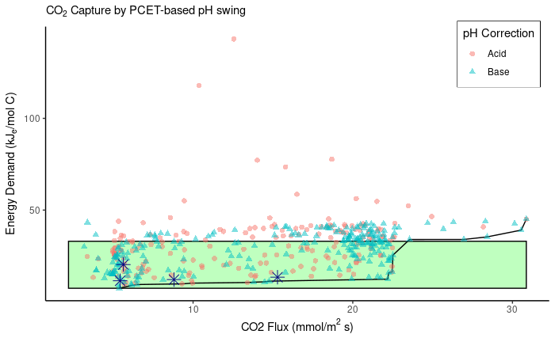

```r
sz = 2
ggplot() +
  geom_rect(reg.full,
            mapping = aes(xmin = min.flux*1e3, xmax = max.flux*1e3, ymin = min.ener, ymax = max.ener),
            fill = 'green', linetype = 1, color = 'black', alpha = 0.25) +
  geom_line(GPar.front, mapping = aes(x = Flux.mol.m2s*1e3, y = Energy.kJ.mol), color = 'black') +
  geom_point(filter(GPar.nat, Energy.kJ.mol < 150, Flux.mol.m2s > 0),
             mapping = aes(x = Flux.mol.m2s*1e3, y = Energy.kJ.mol, color = as.factor(typ), shape = as.factor(typ)),
             size = sz, alpha = 0.5) +
  geom_point(filter(region.pk, Energy.kJ.mol < 150, Flux.mol.m2s > 0, reg == '1'),
             mapping = aes(x = Flux.mol.m2s*1e3, y = Energy.kJ.mol), color = 'navy',
             shape = 8, size = sz*2) +
  labs(x = expression('CO2 Flux (mmol/m'^2*' s)'), y = expression('Energy Demand (kJ'['e']*'/mol C)'),
       subtitle = expression('CO'[2]*' Capture by PCET-based pH swing'), color = 'pH Correction', shape = 'pH Correction') +
  theme_classic() + theme(legend.position = c(0.9, 0.9),
                          legend.box.background = element_rect(color = 'black', linetype = 1)) +
  # scale_x_log10() + scale_y_log10() +
  guides(fill = FALSE) + scale_color_discrete(labels = c('Acid', 'Base')) + scale_shape_discrete(labels = c('Acid', 'Base'))
```

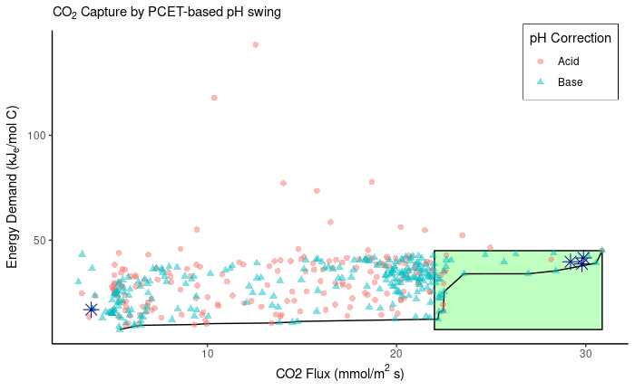

```r
ggplot() +
  geom_rect(reg.flux,
            mapping = aes(xmin = min.flux*1e3, xmax = max.flux*1e3, ymin = min.ener, ymax = max.ener),
            fill = 'green', linetype = 1, color = 'black', alpha = 0.25) +
  geom_line(GPar.front, mapping = aes(x = Flux.mol.m2s*1e3, y = Energy.kJ.mol), color = 'black') +
  geom_point(filter(GPar.nat, Energy.kJ.mol < 150, Flux.mol.m2s > 0),
             mapping = aes(x = Flux.mol.m2s*1e3, y = Energy.kJ.mol, color = as.factor(typ), shape = as.factor(typ)),
             size = sz, alpha = 0.5) +
  geom_point(filter(region.pk, Energy.kJ.mol < 100, Flux.mol.m2s > 0, reg == '2'),
             mapping = aes(x = Flux.mol.m2s*1e3, y = Energy.kJ.mol), color = 'navy',
             shape = 8, size = sz*2) +
  labs(x = expression('CO2 Flux (mmol/m'^2*' s)'), y = expression('Energy Demand (kJ'['e']*'/mol C)'),
       subtitle = expression('CO'[2]*' Capture by PCET-based pH swing'), color = 'pH Correction', shape = 'pH Correction') +
  theme_classic() + theme(legend.position = c(0.9, 0.9),
                          legend.box.background = element_rect(color = 'black', linetype = 1)) +
  # scale_x_log10() + scale_y_log10() +
  guides(fill = FALSE) + scale_color_discrete(labels = c('Acid', 'Base')) + scale_shape_discrete(labels = c('Acid', 'Base'))
```

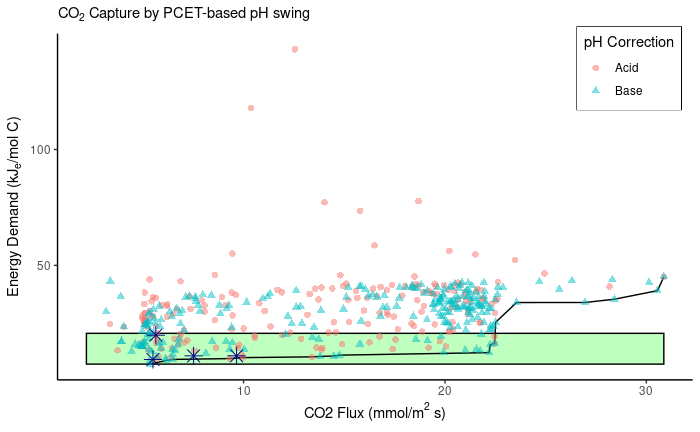

```r
ggplot() +
  geom_rect(reg.ener,
            mapping = aes(xmin = min.flux*1e3, xmax = max.flux*1e3, ymin = min.ener, ymax = max.ener),
            fill = 'green', linetype = 1, color = 'black', alpha = 0.25) +
  geom_line(GPar.front, mapping = aes(x = Flux.mol.m2s*1e3, y = Energy.kJ.mol), color = 'black') +
  geom_point(filter(GPar.nat, Energy.kJ.mol < 150, Flux.mol.m2s > 0),
             mapping = aes(x = Flux.mol.m2s*1e3, y = Energy.kJ.mol, color = as.factor(typ), shape = as.factor(typ)),
             size = sz, alpha = 0.5) +
  geom_point(filter(region.pk, Energy.kJ.mol < 100, Flux.mol.m2s > 0, reg == '3'),
             mapping = aes(x = Flux.mol.m2s*1e3, y = Energy.kJ.mol), color = 'navy',
             shape = 8, size = sz*2) +
  labs(x = expression('CO2 Flux (mmol/m'^2*' s)'), y = expression('Energy Demand (kJ'['e']*'/mol C)'),
       subtitle = expression('CO'[2]*' Capture by PCET-based pH swing'), color = 'pH Correction', shape = 'pH Correction') +
  theme_classic() + theme(legend.position = c(0.9, 0.9),
                          legend.box.background = element_rect(color = 'black', linetype = 1)) +
  # scale_x_log10() + scale_y_log10() +
  guides(fill = FALSE) + scale_color_discrete(labels = c('Acid', 'Base')) + scale_shape_discrete(labels = c('Acid', 'Base'))
```

```r
region.pk
```

| pka1 | pka2 | logA | Na.A | typ | reg | Energy.kJ.mol | Flux.mol.m2s | suggest |
| --- | --- | --- | --- | --- | --- | --- | --- | --- |
| 6.375274 | 10.72973 | 0.1621622 | -4.3974434 | -1 | 1 | 13.414468 | 0.0152870 | weak |
| 7.632579 | 10.50000 | -1.2905405 | -0.7990869 | 1 | 1 | 11.469951 | 0.0054297 | weak |
| 5.229730 | 10.72973 | -0.3783784 | -3.0925310 | -1 | 1 | 12.120116 | 0.0088029 | strong |
| 9.200511 | 10.50000 | -1.1891892 | -4.3932980 | 1 | 1 | 20.301810 | 0.0056362 | strong |
| 11.376552 | 16.70270 | 0.4662162 | -2.7682432 | -1 | 2 | 38.668177 | 0.0298000 | weak |
| 12.121622 | 17.62162 | 0.4662162 | 1.2000000 | 1 | 2 | 16.888939 | 0.0038657 | weak |
| 12.261322 | 16.70270 | 0.4662162 | -1.2562454 | -1 | 2 | 41.540365 | 0.0298800 | strong |
| 12.261322 | 17.62162 | 0.4662162 | -0.4018992 | 1 | 2 | 39.713695 | 0.0291950 | strong |
| 4.838568 | 10.27027 | -0.2770270 | -4.2080168 | -1 | 3 | 10.969452 | 0.0096565 | weak |
| 5.676771 | 10.50000 | -1.2567568 | -0.9104456 | 1 | 3 | 9.402735 | 0.0055032 | weak |

[output cut: 2 more lines]

# Points of interest

Specific points of interest are:

- Peak performance according to the 1D conditional marginals (strong condition, base addition)
- Poor performance according to those marginals (strong condition, base addition)
- Point near the maximum flux
- Point near the concavity in the Pareto front
- Point near the minimum energy demand

New function to output all relevant process parameters (xA, DIC, pH, pCO2, electrode potential) over the course of the capture cycle.

```r
PCET.cycle = function(pka1, pka2, logA, Na.A, acid){
  # Set up algorithm constants
  z = 2; R = 8.314; T = 298; F = 96485; resolution = 201;
  pCO2.in = 0.15; pCO2.out = 1
  xA.lim = c(.025, 0.975)

  # Convert from search space natural variable units to typical units for calculations
  beta1 = 0; beta2 = 0;
  k1 = 10^-pka1; k2 = 10^-pka2
  A.tot = 10^logA; Na = acid*10^Na.A

  # Start with end of absorbing step: low P, high xA
  start.soln = data.frame(p.CO2 = pCO2.in, xA = max(xA.lim))
  start.soln$pH = pH.xA.pCO2.A.k.beta.Na(xA = start.soln$xA, P = start.soln$p.CO2,
                                         At = A.tot, k1 = k1, k2 = k2, beta1 = beta1, beta2 = beta2, Na = Na)
  start.soln$DIC = DIC.xA.pCO2.pH.A.k.beta(xA = start.soln$xA, pCO2 = start.soln$p.CO2, pH = start.soln$pH,
                                           A.tot = A.tot, k1 = k1, k2 = k2, beta1 = beta1, beta2 = beta2)
  # start.soln

  # Check that the condition will pump CO2 (pressure of fully oxidized state is > outlet)
  stop.soln = data.frame(p.CO2 = pCO2.out, xA = min(xA.lim))
  stop.soln$pH = pH.xA.pCO2.A.k.beta.Na(xA = stop.soln$xA, P = stop.soln$p.CO2,
                                       At = A.tot, k1 = k1, k2 = k2, beta1 = beta1, beta2 = beta2, Na = Na)
  stop.soln$DIC = DIC.xA.pCO2.pH.A.k.beta(xA = stop.soln$xA, pCO2 = stop.soln$p.CO2, pH = stop.soln$pH,
                                         A.tot = A.tot, k1 = k1, k2 = k2, beta1 = beta1, beta2 = beta2)


  # 1 -> 2: Electrochemical oxidation (xA decrease to endpoint), constant DIC
  soln12 = data.frame(DIC = start.soln$DIC, xA = seq(from = start.soln$xA[1], to = min(xA.lim), length.out = resolution))
  # Loop to solve the ieration function
  loop = pH.it.guess.DIC.At.k.beta(pH.guess = start.soln$pH[1], xA.next = soln12$xA[1], DIC = soln12$DIC[1],
                                       A.tot = A.tot, k1 = k1, k2 = k2, beta1 = beta1, beta2 = beta2, Na = Na)
  for(i in 2:length(soln12$DIC)){
    loop = c(loop, pH.it.guess.DIC.At.k.beta(pH.guess = loop[i-1], xA.next = soln12$xA[i], DIC = soln12$DIC[i],
                                         A.tot = A.tot, k1 = k1, k2 = k2, beta1 = beta1, beta2 = beta2, Na = Na))
  }
  soln12$pH = loop;
  # Loop pCO2 calculation as well, since the pCO2 function relies on the previous point
  loop = pCO2.xA.pH.A.k.beta.Na(xA = soln12$xA[1], pH = soln12$pH[1],
                                At = A.tot, k1 = k1, k2 = k2, beta1 = beta1, beta2 = beta2, Na = Na, pCO2.prev = start.soln$p.CO2)
  for(i in 2:length(soln12$DIC)){
    loop[i] = pCO2.xA.pH.A.k.beta.Na(xA = soln12$xA[i], pH = soln12$pH[i],
                                  At = A.tot, k1 = k1, k2 = k2, beta1 = beta1, beta2 = beta2, Na = Na, pCO2.prev = loop[i-1])
  }
  soln12$p.CO2 = loop
  soln12$stage = "1->2"
  soln12$q = abs(soln12$xA - soln12$xA[1])*A.tot*z*F # Coulombs

  # 2 -> 3: Outgassing (pCO2 decreases until outlet), constant xA
  soln23 = data.frame(xA = soln12$xA[resolution], p.CO2 = seq(from = soln12$p.CO2[resolution], to = pCO2.out, length.out = resolution))
  # Solve pH with multiple cores
  soln23$pH = mcmapply(pH.xA.pCO2.A.k.beta.Na, xA = soln23$xA, P = soln23$p.CO2,
                       At = A.tot, k1 = k1, k2 = k2, beta1 = beta1, beta2 = beta2, Na = Na)
  soln23$DIC = DIC.xA.pCO2.pH.A.k.beta(xA = soln23$xA, pCO2 = soln23$p.CO2, pH = soln23$pH,
                                       A.tot = A.tot, k1 = k1, k2 = k2, beta1 = beta1, beta2 = beta2)
  soln23$stage = "2->3"
  soln23$q = soln12$q[resolution]

  # 3 -> 4: Electrochemical reduction (xA increase to endpoint), constant DIC
  soln34 = data.frame(DIC = soln23$DIC[resolution], xA = seq(from = soln23$xA[1], to = max(xA.lim), length.out = resolution))
  # Loop to solve the ieration function
  loop = pH.it.guess.DIC.At.k.beta(pH.guess = soln23$pH[resolution], xA.next = soln34$xA[1], DIC = soln34$DIC[1],
                                       A.tot = A.tot, k1 = k1, k2 = k2, beta1 = beta1, beta2 = beta2, Na = Na)
  for(i in 2:length(soln12$DIC)){
    loop = c(loop, pH.it.guess.DIC.At.k.beta(pH.guess = loop[i-1], xA.next = soln34$xA[i], DIC = soln34$DIC[i],
                                         A.tot = A.tot, k1 = k1, k2 = k2, beta1 = beta1, beta2 = beta2, Na = Na))
  }
  soln34$pH = loop;
  # Loop pCO2 calculation as well, since the pCO2 function relies on the previous point
  loop = pCO2.xA.pH.A.k.beta.Na(xA = soln34$xA[1], pH = soln34$pH[1],
                                At = A.tot, k1 = k1, k2 = k2, beta1 = beta1, beta2 = beta2, Na = Na, pCO2.prev = stop.soln$p.CO2)
  for(i in 2:length(soln34$DIC)){
    loop[i] = pCO2.xA.pH.A.k.beta.Na(xA = soln34$xA[i], pH = soln34$pH[i],
                                  At = A.tot, k1 = k1, k2 = k2, beta1 = beta1, beta2 = beta2, Na = Na, pCO2.prev = loop[i-1])
  }
  soln34$p.CO2 = loop
  soln34$stage = "3->4"
  soln34$q = abs(soln34$xA - soln34$xA[1])*A.tot*z*F # Coulombs

  # 4 -> 1: Absorbing (pCO2 increase until inlet), constant xA
  soln41 = data.frame(xA = soln34$xA[resolution], p.CO2 = seq(from = soln34$p.CO2[resolution], to = pCO2.in, length.out = resolution))
  # Solve pH with multiple cores
  soln41$pH = mcmapply(pH.xA.pCO2.A.k.beta.Na, xA = soln41$xA, P = soln41$p.CO2,
                       At = A.tot, k1 = k1, k2 = k2, beta1 = beta1, beta2 = beta2, Na = Na)
  soln41$DIC = DIC.xA.pCO2.pH.A.k.beta(xA = soln41$xA, pCO2 = soln41$p.CO2, pH = soln41$pH,
                                       A.tot = A.tot, k1 = k1, k2 = k2, beta1 = beta1, beta2 = beta2)
  soln41$stage = "4->1"
  soln41$q = soln34$q[resolution]

  return(rbind(soln12, soln23, soln34, soln41))
}

PCET.electrode = function(soln.path, pka1, pka2){
  # Separate electrode processes
  E.anode = filter(soln.path, stage == "1->2")
  E.cathode = filter(soln.path, stage == "3->4")

  # Constants
  z = 2; T = 298; R = 8.314; F = 96485;
  k1 = 10^-pka1; k2 = 10^-pka2
  beta1 = 0; beta2 = 0
  # Equilibrium potential: Deviation from standard reduction potential
  E.anode$H = 10^-E.anode$pH
  E.anode$E = R*T/(z*F) * log( (1 - E.anode$xA)/E.anode$xA *
                                   ((1 + beta1*E.anode$p.CO2 + beta2*E.anode$p.CO2^2)*k1*k2 + k1*E.anode$H + E.anode$H^2)/(k1*k2))
  E.cathode$H = 10^-E.cathode$pH
  E.cathode$E = R*T/(z*F) * log( (1 - E.cathode$xA)/E.cathode$xA *
                                   ((1 + beta1*E.cathode$p.CO2 + beta2*E.cathode$p.CO2^2)*k1*k2 + k1*E.cathode$H + E.cathode$H^2)/(k1*k2))

  # Repeat the end points for plotting purposes
  E.cell = rbind(E.anode, E.cathode)
  degas = filter(E.cell, xA == min(xA)); degas$stage = '2->3'
  E.cell = rbind(E.cathode, E.anode)
  catch = filter(E.cell, xA == max(xA)); catch$stage = '4->1'
  return(rbind(E.anode, degas, E.cathode, catch))

  # Total energy
  # E.cell = data.frame(q = E.anode$q, V = E.anode$E - E.cathode$E, xA = E.anode$xA)
  # Energy.tot = (E.cell$q[resolution]-E.cell$q[1])/resolution * (E.cell$V[1] + E.cell$V[resolution] + 2*sum(E.cell$V[2:(resolution-1)]))/2
  # Energy.norm = Energy.tot/(E.anode$DIC[1] - E.cathode$DIC[1])
}
```

Specific points of interest are:

```r
# Load data
GPar.all = read.csv(file = 'GPar_AcidBase_data.csv')
GPar.front = read.csv(file = 'GPar_AcidBase_fnt.csv')
# Remove unneeded variables
GPar.all = GPar.all[,!(names(GPar.all) %in% c('X', 'X.1'))]
GPar.front = GPar.front[,!(names(GPar.front) %in% c('X', 'X.1'))]

# Cutoff levels
E.cutof = log10(40); #kJ/mol C, log units
F.cutof = 0.1*max(GPar.all$Flux.mol.m2s)
sz = 2

# Natural variables conversion
GPar.nat = GPar.all
GPar.nat$pka2 = GPar.nat$pka1 + GPar.nat$pka2
GPar.nat$Na.A = GPar.nat$logA + GPar.nat$Na.A

# For acid/base, low additions (<10^-7) are effectively no additions
GPar.nat$typ.none = GPar.nat$typ
GPar.nat$typ.none[GPar.nat$Na.A < -7] = 'None'

# Target points based on the Pareto front
# pKa1 = 4.92, pka2 = 9.49, {Q} = 23 mM, {HX} = 6.6 mM
test.sys = data.frame(pka1 = c(region.pk$pka1[7],  7.35,   region.pk$pka1[9], 4.92),
                      pka2 = c(region.pk$pka2[7],   11.25, region.pk$pka2[9], 9.49),
                      logA = c(region.pk$logA[7],   0.5,   region.pk$logA[9], -1.63),
                      Na.A = c(region.pk$Na.A[7],   -1,    region.pk$Na.A[9], -2.18),
                      acid = c(region.pk$typ[7],   -1,     region.pk$typ[9], -1),
                      label = c('Global High Flux', 'Local High Flux', 'Low Energy', 'Bad Result') )
# # Target points based on the marginals - best, worst, and 1-variable exchanges
exch.sys = data.frame(pka1 = rep(reg.full.ranges$pka1.pk.wk[1], 5),
                      pka2 = rep(reg.full.ranges$pka2.pk.wk[1], 5),
                      logA = rep(reg.full.ranges$logA.pk.wk[1], 5),
                      Na.A = rep(reg.full.ranges$Na.A.pk.wk[1], 5), acid = rep(1, 5))
poor = c(reg.full.ranges$pka1.lo.st[2], reg.full.ranges$pka2.lo.st[2],
         reg.full.ranges$logA.lo.st[2], reg.full.ranges$Na.A.lo.st[2])
wt = 0.45 # Weighted average so it does not move too far; interested in relatively small perturbations
for(i in 1:length(poor)){
  exch.sys[i,i] = wt*exch.sys[i,i] + (1-wt)*poor[i]
}
# This selection does lead to extrapolation of the model outside of the pka difference that is real
rm(poor)
exch.sys$label = c('Bad pka1', 'Bad pka2', 'Bad {Quinone}', 'Bad {pH Correction}', 'Peak Prediction')

test.sys = rbind(test.sys, exch.sys)
rm(exch.sys)

# Solve results
res = PCET.obj.flu(inputs = as.matrix(test.sys[,c('pka1', 'pka2', 'logA', 'Na.A', 'acid')]))
test.sys$Energy.kJ.mol = res[1:nrow(test.sys)]
test.sys$Flux.mol.m2s = res[(nrow(test.sys)+1):length(res)]
# Normalized distance due to the single variable change
test.sys$dist = sqrt((test.sys$Energy.kJ.mol - test.sys$Energy.kJ.mol[8])^2/test.sys$Energy.kJ.mol[8]^2 +
  (test.sys$Flux.mol.m2s - test.sys$Flux.mol.m2s[8])^2/test.sys$Flux.mol.m2s[8]^2)
# test.sys$dist = sqrt((test.sys$Energy.kJ.mol - test.sys$Energy.kJ.mol[8])^2/reg.full$max.ener^2 +
#   (test.sys$Flux.mol.m2s - test.sys$Flux.mol.m2s[8])^2/reg.full$max.flux^2)
test.sys
```

| pka1 | pka2 | logA | Na.A | acid | label | Energy.kJ.mol | Flux.mol.m2s | dist |
| --- | --- | --- | --- | --- | --- | --- | --- | --- |
| 12.261322 | 16.702703 | 0.4662162 | -1.256245 | -1 | Global High Flux | 41.54037 | 0.0298800 | 2.303799e+00 |
| 7.350000 | 11.250000 | 0.5000000 | -1.000000 | -1 | Local High Flux | 17.16775 | 0.0225270 | 5.500856e-01 |
| 4.838568 | 10.270270 | -0.2770270 | -4.208017 | -1 | Low Energy | 10.96945 | 0.0096565 | 4.109468e-01 |
| 4.920000 | 9.490000 | -1.6300000 | -2.180000 | -1 | Bad Result | 25.78559 | 0.0048999 | 1.145520e+00 |
| 4.860765 | 10.729730 | 0.1621622 | -4.397443 | 1 | Bad pka1 | 12.28287 | 0.0152870 | 8.434620e-02 |
| 6.375274 | 8.202703 | 0.1621622 | -4.397443 | 1 | Bad pka2 | 27.41306 | 0.0112020 | 1.077236e+00 |
| 6.375274 | 10.729730 | -1.0270270 | -4.397443 | 1 | Bad {Quinone} | 13.55276 | 0.0059592 | 6.102659e-01 |
| 6.375274 | 10.729730 | 0.1621622 | -6.612971 | 1 | Bad {pH Correction} | 13.41432 | 0.0152870 | 0.000000e+00 |
| 6.375274 | 10.729730 | 0.1621622 | -4.397443 | 1 | Peak Prediction | 13.41418 | 0.0152870 | 1.080594e-05 |

```r
# For plotting purposes
test.sys$Energy.kJ.mol[test.sys$Energy.kJ.mol > 100] = 100
test.sys$Flux.mol.m2s[test.sys$Flux.mol.m2s < 0] = 0
typ = rep('+Acid', nrow(test.sys))
typ[test.sys$typ == 1] = '+Base'
test.sys$typ = typ
test.sys
```

| pka1 | pka2 | logA | Na.A | acid | label | Energy.kJ.mol | Flux.mol.m2s | dist | typ |
| --- | --- | --- | --- | --- | --- | --- | --- | --- | --- |
| 12.261322 | 16.702703 | 0.4662162 | -1.256245 | -1 | Global High Flux | 41.54037 | 0.0298800 | 2.303799e+00 | +Acid |
| 7.350000 | 11.250000 | 0.5000000 | -1.000000 | -1 | Local High Flux | 17.16775 | 0.0225270 | 5.500856e-01 | +Acid |
| 4.838568 | 10.270270 | -0.2770270 | -4.208017 | -1 | Low Energy | 10.96945 | 0.0096565 | 4.109468e-01 | +Acid |
| 4.920000 | 9.490000 | -1.6300000 | -2.180000 | -1 | Bad Result | 25.78559 | 0.0048999 | 1.145520e+00 | +Acid |
| 4.860765 | 10.729730 | 0.1621622 | -4.397443 | 1 | Bad pka1 | 12.28287 | 0.0152870 | 8.434620e-02 | +Acid |
| 6.375274 | 8.202703 | 0.1621622 | -4.397443 | 1 | Bad pka2 | 27.41306 | 0.0112020 | 1.077236e+00 | +Acid |
| 6.375274 | 10.729730 | -1.0270270 | -4.397443 | 1 | Bad {Quinone} | 13.55276 | 0.0059592 | 6.102659e-01 | +Acid |
| 6.375274 | 10.729730 | 0.1621622 | -6.612971 | 1 | Bad {pH Correction} | 13.41432 | 0.0152870 | 0.000000e+00 | +Acid |
| 6.375274 | 10.729730 | 0.1621622 | -4.397443 | 1 | Peak Prediction | 13.41418 | 0.0152870 | 1.080594e-05 | +Acid |

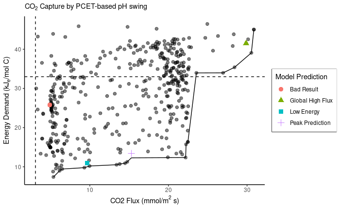

```r
# Update GPar.front with the predicted points
front = data.frame(x1 = c(GPar.front$Energy.kJ.mol, test.sys$Energy.kJ.mol),
                   x2 = -c(GPar.front$Flux.mol.m2s, test.sys$Flux.mol.m2s))
test = as.matrix(front)
# For the Pareto front determination, need both to minimize
par.front = t(nondominated_points(points = t(test)))
par.front[,2] = -par.front[,2]
# Identify the conditions leading to the Pareto front
GPar.front = filter(rbind(GPar.front[, names(GPar.front) %in% names(test.sys)],
                          test.sys[, names(test.sys) %in% names(GPar.front)]),
                    Energy.kJ.mol %in% par.front[,1], Flux.mol.m2s %in% par.front[,2])

# Good points
ggplot() +
  # Data and guide lines
  geom_line(GPar.front, mapping = aes(x = Flux.mol.m2s*1e3, y = Energy.kJ.mol), color = 'black') +
  geom_hline(yintercept = 33, color = 'black', linetype = 2) +
  geom_vline(xintercept = 0.1*max(GPar.front$Flux.mol.m2s)*1e3, color = 'black', linetype = 2) +
  geom_point(filter(GPar.nat, Energy.kJ.mol < 50, Flux.mol.m2s > 0),
             mapping = aes(x = Flux.mol.m2s*1e3, y = Energy.kJ.mol), size = sz, color = 'black', alpha = 0.5) +
  # Good points of interest
  geom_point(data = filter(test.sys)[c(1, 3, 4, 9),],
  # geom_point(data = filter(test.sys)[c(1:3, 8),],
             mapping = aes(x = Flux.mol.m2s*1e3, y = Energy.kJ.mol, color = label, shape = label),
             size = 3) +
  labs(x = expression('CO2 Flux (mmol/m'^2*' s)'), y = expression('Energy Demand (kJ'['e']*'/mol C)'),
       subtitle = expression('CO'[2]*' Capture by PCET-based pH swing'),
       color = 'Model Prediction', shape = 'Model Prediction') +
  theme_classic() + theme(#legend.position = c(0.9, 0.9),
                          legend.box.background = element_rect(color = 'black', linetype = 1))
```

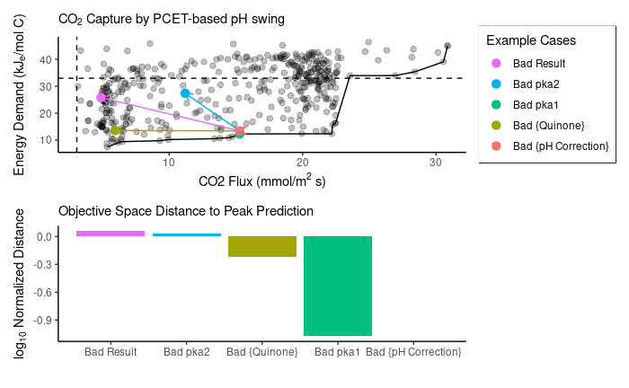

```r
# Bad points relative to peak probability
g.points = ggplot() +
  # Data and guide lines
  geom_line(GPar.front, mapping = aes(x = Flux.mol.m2s*1e3, y = Energy.kJ.mol), color = 'black') +
  geom_hline(yintercept = 33, color = 'black', linetype = 2) +
  geom_vline(xintercept = 0.1*max(GPar.front$Flux.mol.m2s)*1e3, color = 'black', linetype = 2) +
  geom_point(filter(GPar.nat, Energy.kJ.mol < 50, Flux.mol.m2s > 0),
             mapping = aes(x = Flux.mol.m2s*1e3, y = Energy.kJ.mol), size = sz, color = 'black', alpha = 0.25) +
  # Single variable changes: draw arrow from original spot
  geom_segment(data = filter(test.sys, Energy.kJ.mol <= 100, Flux.mol.m2s >= 0)[-c(1:3, 9),],
             mapping = aes(x = test.sys$Flux.mol.m2s[8]*1e3, y = test.sys$Energy.kJ.mol[8],
                           xend = Flux.mol.m2s*1e3, yend = Energy.kJ.mol, color = label),
             arrow = arrow(length = unit(0.25, "cm"))) +
  geom_point(data = filter(test.sys, Energy.kJ.mol <= 100, Flux.mol.m2s >= 0)[-c(1:3, 9),],
             mapping = aes(x = Flux.mol.m2s*1e3, y = Energy.kJ.mol, color = label),
             shape = 19, size = 3) +
  labs(x = expression('CO2 Flux (mmol/m'^2*' s)'), y = expression('Energy Demand (kJ'['e']*'/mol C)'),
       subtitle = expression('CO'[2]*' Capture by PCET-based pH swing'),
       color = 'Example Cases') +
  theme_classic() + theme(legend.box.background = element_rect(color = 'black', linetype = 1)) +
  guides(shape = FALSE, color = guide_legend(override.aes = list(shape = 19, linetype = NA), reverse = TRUE))

# Distance of peak probability to single-variable changes
test.plt = test.sys[-c(1:3, 9),]
g.dist = ggplot(test.plt[order(test.plt$dist, decreasing = TRUE),]) +
  geom_col(mapping = aes(x = 1:nrow(test.plt),
                         y = log10(dist), fill = label)) +
  labs(x = '', y = expression('log'[10]*' Normalized Distance'),
       fill = '', subtitle = 'Objective Space Distance to Peak Prediction') +
  theme_classic() +  guides(fill = FALSE) +
  scale_x_continuous(breaks = 1:nrow(test.plt),
                     labels = test.plt[order(test.plt$dist, decreasing = TRUE),]$label)

g.points / g.dist
```

```r
rm(test.plt, g.points, g.dist)
```

The “bad point” suggested by marginals was too far from the other points such that interpreting the impact of each variable was hard to untangle. Instead, we picked a point with moderate energy demand but low flux to contrast with the low energy-moderate flux and the high energy-high flux suggestions.